[figure not shown]

# Проект на тему: "Идентификация пользователя по его активности в интернете"

Исполнитель: Глазунов А.В.

### 1. Вступительная часть

Данный проект подготовлен в рамках прохождения специализации **"Машинное обучение и анализ данных"** на платформе Coursera и посвящен проблеме идентификации одного пользователи по его сессиям. Данный отчет о проекте представлен в виде ipython notebook,а полезные материалы, полученные на стадии решения заданий финального курса специализации, представлены отдельным файлом. В рамках проекта решается задача идентификации пользователя на примере соревнования Kaggle **"Catch me if you can"**. Имеются файлы с сессиями для обучения и теста, при этом сессии составлены так, что в них не может быть больше 10 сайтов, а их длительности ограничены 30 минутами.

*Импортируем полезные библиотеки, а также делаем удобные установки*

```python
from __future__ import print_function
import warnings
warnings.filterwarnings('ignore')

import numpy as np
import pandas as pd
pd.set_option('display.max.columns', 50)
import itertools
import random
import os
import re
from glob import glob
import scipy
from scipy.sparse import csr_matrix,hstack
from tqdm import tqdm_notebook
from time import time
import pickle

from sklearn.feature_extraction.text import TfidfTransformer
from sklearn.preprocessing import LabelEncoder
from sklearn.preprocessing import StandardScaler
from sklearn.metrics import  accuracy_score,roc_auc_score,f1_score,classification_report,roc_curve, confusion_matrix
from sklearn.metrics import make_scorer,precision_score,recall_score
from sklearn.model_selection import train_test_split,cross_val_score, StratifiedKFold, GridSearchCV
from sklearn.model_selection import learning_curve
from sklearn.linear_model import SGDClassifier
from sklearn.ensemble import RandomForestClassifier
from sklearn.naive_bayes import MultinomialNB
from sklearn.neighbors import KNeighborsClassifier
import xgboost as xgb

from scipy import stats
from scipy.stats import pearsonr
from statsmodels.stats.proportion import proportion_confint
from statsmodels.stats.weightstats import _tconfint_generic


import seaborn as sns
sns.set_style("darkgrid")
from matplotlib import pyplot as plt
%matplotlib inline

from plotly.offline import iplot
import plotly.graph_objs as go


from ipywidgets import interactive
import ipywidgets as widgets

from sklearn.manifold import TSNE
```

*Информация о системе и версиях*

```python
%load_ext watermark
%watermark -v -m -p numpy,scipy,pandas,matplotlib,statsmodels,sklearn
```

```
CPython 3.7.3
IPython 7.6.1

numpy 1.16.4
scipy 1.2.1
pandas 0.24.2
matplotlib 3.1.0
statsmodels 0.9.0
sklearn 0.22.2.post1

compiler   : MSC v.1915 64 bit (AMD64)
system     : Windows
release    : 10
machine    : AMD64
processor  : Intel64 Family 6 Model 142 Stepping 12, GenuineIntel
CPU cores  : 4
interpreter: 64bit
```

Несмотря на то, что файлы с сессиями имеются в данных соревнования, на практике их формирование является творческой задачей. Для получения выборок напрямую из файлов пользователей с их сессиями можно использовать несколько описанных ниже функций.

Функция ниже получает на вход пути к файлам пользователей и возвращает таблицу с сессиями и словарь, где сайты отсортированы по убыванию частоты просмотров. Сайты в сессиях отображаются по их ID, которые являются позициями в словаре.

```python
def prepare_train_set(path_to_csv_files, session_length=10):

    #Загрузка данных
    files_paths = list(glob(os.path.join(path_to_csv_files,'user*.csv')))

    files = []
    user_IDs = []
    for path in tqdm_notebook(files_paths):
        f_name = os.path.split(path)[1]
        ID = int(re.findall("[0-9]+",f_name)[0])
        user_IDs.append(ID)
        files.append(pd.read_csv(path))

    #Получение словаря
    sites_dictionary = {}

    for user in tqdm_notebook(files):
        for site in user.site.values:
            if site in sites_dictionary:

                sites_dictionary[site] += 1

            else:
                sites_dictionary[site] = 1

    d =  sorted(sites_dictionary.items(), key=lambda item: item[1],reverse = True)
    sites_dict_sorted = {}

    for ii,pair in enumerate(d):

        sites_dict_sorted[pair[0]] = [ii+1,pair[1]]


    #Получение сессий
    data_list = []

    for ind,user in enumerate(tqdm_notebook(files)):
        session = np.zeros(session_length+1)
        session[session_length] = user_IDs[ind]
        site_position = 0
        for site in user.site.values:
            session[site_position]=sites_dict_sorted[site][0]
            site_position += 1
            if site_position == session_length:
                data_list.append(session)
                session = np.zeros(session_length+1)
                session[session_length] = user_IDs[ind]
                site_position = 0
        if site_position != 0:
            data_list.append(session)

    columns = ['site'+str(num) for num in range(1,session_length+1)]+['user_ID']
    data = pd.DataFrame(data_list,dtype = int)
    data.columns= columns




    return data,sites_dict_sorted
```

Для работы с данными можно использовать подход 'Мешка сайтов', в рамках которого каждая сессия будет вектором длины словаря с огромным количеством нулей. Для нескольких пользователей можно использовать плотный формат, но в случае более 100 пользователей оперативная память может не вместить данные, будет ошибка. Для перевода данных в разреженный формат можно воспользоваться следующей функцией.

```python
def to_sparse_format(X):
    data = np.ones(X.size, dtype=int)
    indices = X.reshape(-1)
    indptr = np.arange(X.shape[0] + 1) * X.shape[1]
    return csr_matrix((data, indices, indptr), dtype=int)[:, 1:]
```

Можно заметить, что столбец нулей удаляется, это связано с тем, что 0 означает отсутствие сайта, при этом в словаре сайты нумеруются с 1.

Для получения сессий можно использовать также окна заданной ширины. Так, в случае длины сессии 10 и ширины окна 5 мы проходим 10 сайтов, заканчиваем сессию, но новую сессию начинаем не с 11 сайта, а с 6-го. Такой подход может дать прирост в качестве классификации. К примеру, в мультиклассой задаче с 10 пользователями наилучший результат показали длина сессии 15 с шириной окна 5. Ниже представлена функция, которая на вход получает пути к файлам пользователей, а на выходе мы имеем уже обучающую выборку и вектор отклика.

```python
def prepare_sparse_train_set_window(path_to_csv_files, site_freq_path,
                                    session_length=10, window_size=10):

    #Загрузка файлов пользователей
    files_paths = list(glob(os.path.join(path_to_csv_files,'user*.csv')))
    files = []
    user_IDs = []
    for path in tqdm_notebook(files_paths):
        f_name = os.path.split(path)[1]
        ID = int(re.findall("[0-9]+",f_name)[0])
        user_IDs.append(ID)
        files.append(pd.read_csv(path))
    user_IDs = np.array(user_IDs)

    #Получение словаря сайтов с ID и частотами
    if (session_length==10) and (window_size==10):#если так, то подгружаем уже готовый
        with open(site_freq_path,'rb') as f:
            sites_dict_sorted = pickle.load(f)
        f.close()
    else:        #иначе создаем из файлов пользователй
        sites_dictionary = {}

        for user in tqdm_notebook(files):
            for site in user.site.values:
                if site in sites_dictionary:

                    sites_dictionary[site] += 1

                else:
                    sites_dictionary[site] = 1

        d =  sorted(sites_dictionary.items(), key=lambda item: item[1],reverse = True)
        sites_dict_sorted = {}

        for ii,pair in enumerate(d):

            sites_dict_sorted[pair[0]] = [ii+1,pair[1]]  #заполнение словаря ID и частотами из отсортированного d


    # Заполнение таблицы пользовательских сессий ID просмотренных пользователем сайтов
    Session_list = []

    for ind,user in enumerate(tqdm_notebook(files)):
        session = np.zeros(session_length+1)
        session[session_length] = user_IDs[ind] #заполнение стобца ID пользователей

        sites = user.site.values
        ufile_length = sites.shape[0]
        site_position = 0 #позиция в сессии
        pos_in_ufile = 0 #позиция в файле
        while pos_in_ufile < ufile_length:
            session[site_position]=sites_dict_sorted[sites[pos_in_ufile]][0]#получение ID сайта из словаря по названию
            pos_in_ufile += 1
            site_position += 1

            if site_position == session_length:
                Session_list.append(session)
                session = np.zeros(session_length+1)
                session[session_length] = user_IDs[ind]
                site_position = 0
                pos_in_ufile -= session_length - window_size

            if (pos_in_ufile == ufile_length) & (site_position != 0):
                Session_list.append(session)
                if site_position > window_size:
                    session = np.zeros(session_length+1)
                    session[session_length] = user_IDs[ind]
                    pos_in_ufile -= site_position - window_size
                    site_position = 0


    Sessions = np.array(Session_list,dtype = int)

    #Отделений ID пользователей от таблицы
    X, y = Sessions[:,:-1],Sessions[:,-1]

    #Получение разреженной матрицы частот встречаемости сайтов в каждой сессии

    data = np.ones(X.size, dtype=int)
    indices = X.reshape(-1)
    indptr = np.arange(X.shape[0] + 1) * X.shape[1]

    X_sparse = csr_matrix((data, indices, indptr), dtype=int)[:,1:]


    return X_sparse, y
```

Для улучшения качества классификации, из файлов пользователей можно получить в дополнение к сессиям еще и другие признаки. Ниже представлена функция, которая принимает пути к файлам, а возвращает сессии с дополнительными признаками (см. описание).

```python
def feature_engineering(path_to_csv_files, site_freq_path, feature_names,
                                    session_length=10, window_size=10):

    #Загрузка файлов пользователей
    files_paths = list(glob(os.path.join(path_to_csv_files,'user*.csv')))
    files = []
    user_IDs = []
    for path in tqdm_notebook(files_paths):
        f_name = os.path.split(path)[1]
        ID = int(re.findall("[0-9]+",f_name)[0])
        user_IDs.append(ID)
        files.append(pd.read_csv(path))
    user_IDs = np.array(user_IDs)

    #Получение словаря сайтов с ID и частотами
    if (session_length==10) and (window_size==10):#если так, то подгружаем уже готовый
        with open(site_freq_path,'rb') as f:
            sites_dict_sorted = pickle.load(f)
        f.close()
    else:        #иначе создаем из файлов пользователй
        sites_dictionary = {}

        for user in tqdm_notebook(files):
            for site in user.site.values:
                if site in sites_dictionary:

                    sites_dictionary[site] += 1

                else:
                    sites_dictionary[site] = 1

        d =  sorted(sites_dictionary.items(), key=lambda item: item[1],reverse = True)
        sites_dict_sorted = {}

        for ii,pair in enumerate(d):

            sites_dict_sorted[pair[0]] = [ii+1,pair[1]]  #заполнение словаря ID и частотами из отсортированного d


    # Заполнение таблицы пользовательских сессий ID просмотренных пользователем сайтов
    Session_list = []

    for ind,user in enumerate(tqdm_notebook(files)):
        session = np.zeros(len(feature_names))
        session[-1] = user_IDs[ind] #заполнение столбца ID пользователей

        sites = user.site.values
        user.timestamps = pd.to_datetime(user.timestamp)#Столбец даты и времени начала просмотра сайта
        weekdays = user.timestamps.apply(lambda x:x.weekday()).values
        hours = user.timestamps.apply(lambda x:x.time().hour).values
        seconds = user.timestamps.apply(lambda x:x.timestamp()).values


        session[-2] = weekdays[0] # день недели просмотра сайта
        session[-3] = hours[0] # час просмотра сайта

        ufile_length = sites.shape[0]
        site_position = 0 #начальная позиция в сессии
        pos_in_ufile = 0 #начальная позиция в файле
        while pos_in_ufile < ufile_length:
            session[site_position]=sites_dict_sorted[sites[pos_in_ufile]][0]#получение ID сайта из словаря по названию
            if site_position > 0:
                session[site_position + session_length-1] = seconds[pos_in_ufile] -\
                                                            seconds[pos_in_ufile-1] #время просмотра сайта


            #Еще признаки
            site_id = int(session[site_position])
            dict_len = len(sites_dict_sorted)


            #Время просмотра одного из топ-30 сайтов словаря
            if site_position > 0:
                if site_id <= 30:

                    session[-5 - 31 + site_id] += seconds[pos_in_ufile] -\
                                                            seconds[pos_in_ufile-1]


            # Индикаторы посещения топ-30 сайтов из словаря
            if site_id <= 30:
                if session[-5 - 61 + site_id] == 0:
                    session[-5 - 61 + site_id] = 1



            #ПРИЗНАКИ на основе предпочтений посещения сайтов (частоты)

            #Частоты посещения 10 не самых популярных, но более специфичных сайтов, чем лидеры
            if (site_id <= dict_len//50) and (site_id > (dict_len//50)-10):
                position10 = site_id - (dict_len//50-10) #позиция признака по порядку следования (1...10)
                session[-5 - 71 + position10] += 1 #увеличивается частота посещения

            #Частоты посещения 10  самых популярных сайтов
            if site_id <= 10:
                session[-5 - 81 + site_id] += 1 #увеличивается частота посещения



            #конец составления добавочных признаков


            pos_in_ufile += 1 #шаг по файлу
            site_position += 1 #шаг по сессии

            if site_position == session_length: #если достигнут конец сессии
                session[-4] = np.unique(session[:session_length]).shape[0] #Количество уникальных сайтов в сессии
                session[-5] = seconds[pos_in_ufile-1] -\
                                seconds[pos_in_ufile-session_length]     #длительность сессии
                Session_list.append(session) #готовая сессия добавляется в список

                session = np.zeros(len(feature_names))#инициализируется новая сессия
                session[-1] = user_IDs[ind]
                site_position = 0
                pos_in_ufile -= session_length - window_size
                if (pos_in_ufile != ufile_length):#если не достигнут конец файла
                    session[-2] = weekdays[pos_in_ufile]
                    session[-3] = hours[pos_in_ufile]



            if (pos_in_ufile == ufile_length) & (site_position != 0):#если файл закончился раньше сессии

                session[-4] = np.unique(session[:site_position]).shape[0]
                session[-5] = seconds[pos_in_ufile-1]-\
                                    seconds[pos_in_ufile-site_position]
                Session_list.append(session)

                if site_position > window_size:#если каретка вышла за пределы окна (можно начать новую сессию)
                    session = np.zeros(len(feature_names))
                    session[-1] = user_IDs[ind]
                    pos_in_ufile -= site_position - window_size
                    site_position = 0
                    session[-2] = weekdays[pos_in_ufile]
                    session[-3] = hours[pos_in_ufile]


    Sessions = pd.DataFrame(Session_list,columns=feature_names, dtype = int)


    return Sessions
```

Также есть вариант выделения сессий по времени. Ниже представлена функция, которая получает пути к файлам пользователей и время сессии, а на выходе выдает выборку и целевую переменную.

```python
def prepare_sparse_train_set_time(path_to_csv_files,
                                    session_time=5):

    #Загрузка файлов пользователей
    files_paths = list(glob(os.path.join(path_to_csv_files,'user*.csv')))
    files = []
    user_IDs = []
    for path in tqdm_notebook(files_paths):
        f_name = os.path.split(path)[1]
        ID = int(re.findall("[0-9]+",f_name)[0])
        user_IDs.append(ID)
        files.append(pd.read_csv(path))
    user_IDs = np.array(user_IDs)

    #Получение словаря сайтов с ID и частотами

    sites_dictionary = {}

    for user in tqdm_notebook(files):
        for site in user.site.values:
            if site in sites_dictionary:

                sites_dictionary[site] += 1

            else:
                sites_dictionary[site] = 1

    d =  sorted(sites_dictionary.items(), key=lambda item: item[1],reverse = True)
    sites_dict_sorted = {}

    for ii,pair in enumerate(d):

        sites_dict_sorted[pair[0]] = [ii+1,pair[1]]  #заполнение словаря ID и частотами из отсортированного d




    # Заполнение таблицы пользовательских сессий ID просмотренных пользователем сайтов при заданной длительности сессии
    Session_list = []
    for ind,user in enumerate(tqdm_notebook(files)):
        session = []#инициализация сессии
        session.append(user_IDs[ind])#нулевой столбец для ID пользователей

        sites = user.site.values#стоблец сайтов пользователя



        user.timestamps = pd.to_datetime(user.timestamp)#Столбец даты и времени начала просмотра сайта

        seconds = user.timestamps.apply(lambda x:x.timestamp()).values



        ufile_length = sites.shape[0] #длина файла пользователя
        site_position = 0 #позиция в сессии
        pos_in_ufile = 0 #позиция в файле

        duration_time_session = 0
        duration_site_on_last_session = 0
        while pos_in_ufile < ufile_length:
            if pos_in_ufile > 0:
                #Время на сайте в текущей сессии
                duration_time_site =(seconds[pos_in_ufile] - seconds[pos_in_ufile-1])/60. - duration_site_on_last_session
                duration_site_on_last_session  = 0 #новая сессии, величина пока не нужна

                duration_time_session += duration_time_site #увеличиваем время сессии


            if duration_time_session  > session_time:  #время сессии превышено
                Session_list.append(session) #Сессия закончена и помещена в список

                session = [] #инициализация новой сессии
                session.append(user_IDs[ind]) #нулевой столбец для ID пользователей
                site_to_start = sites[pos_in_ufile-1]#последний сайт прошлой переходит на новую сессию
                duration_time_site_over_edge = duration_time_session - session_time#время выхода за пределы
                duration_site_on_last_session  = (seconds[pos_in_ufile] - seconds[pos_in_ufile-1])/60.\
                                                    - duration_time_site_over_edge #время, проведенное на прошлой сессии

                duration_time_session = 0
                session.append(sites_dict_sorted[site_to_start][0])

            elif duration_time_session == session_time:
                Session_list.append(session)

                session = [] #инициализация новой сессии
                session.append(user_IDs[ind]) #нулевой столбец для ID пользователей
                site_to_start = sites[pos_in_ufile]
                duration_time_session = 0
                session.append(sites_dict_sorted[site_to_start][0])
                pos_in_ufile += 1
            else:
                site_to_add =  sites[pos_in_ufile] #сайт для добавления в сессию
                session.append(sites_dict_sorted[site_to_add][0])#добавление
                pos_in_ufile += 1 #переходим на следующую позицию и на след шаге будет проверять время на сайте

        if len(session) > 0: #обрабатываем последнюю сессию для данного пользователя


            Session_list.append(session) #Добавляем последнюю сессию в список



    Sessions = pd.DataFrame(Session_list).fillna(0).values


    #Отделений ID пользователей от таблицы
    X, y = Sessions[:,1:],Sessions[:,0]

    #Получение разреженной матрицы частот встречаемости сайтов в каждой сессии
    data = np.ones(X.size, dtype=int)
    indices = X.reshape(-1)
    indptr = np.arange(X.shape[0] + 1) * X.shape[1]

    X_sparse = csr_matrix((data, indices, indptr), dtype=int)[:,1:]


    return X_sparse, y
```

Отмечу, что выделение сессий по времени с использованием указанной выше функции сильно уменьшило качество алгоритма. Так в задаче с 10 пользователями, доля правильных ответов стала около 60%. Предположительно, это связано с тем, что имеется большое число сайтов, продолжительность просмотра которых настолько большая (данная функция предполагает последовательность просмотра сайтов), что они создают множество сессий с одним сайтом, которые не сильно информативны. Вероятно, более действенным подходом может являться последующее удаление данных сессий из рассмотрения.

Все вышеуказанные функции реализованы для мультиклассового случая. В случае задачи с 10 пользователями доля правильных ответов для логистической регрессии была более 85 %. К сожалению, в задачах 100+ пользователей доля правильных ответов в классификации значительно ниже 50 %. Задача отделения одного выбранного пользователя от остальных решается несколько лучше, но явно проявляется проблема несбалансированности классов, в связи с чем метрика accuracy не показательна. Для перехода к такой бинарной задаче нужно просто перекодировать значения целевой переменной.

Теперь перейдем к данным соревнования Kaggle.

### 2. Первичный анализ данных, подготовка выборок из данных соревнования

Загрузим данные соревнования и посмотрим на них.

```python
PATH_TO_DATA = 'capstone_user_identification'
```

```python
train_df = pd.read_csv(os.path.join(PATH_TO_DATA, 'train_sessions.csv'),
                       index_col='session_id')
test_df = pd.read_csv(os.path.join(PATH_TO_DATA, 'test_sessions.csv'),
                      index_col='session_id')
```

```python
train_df.head()
```

| session_id | site1 | time1 | site2 | time2 | site3 | time3 | site4 | time4 | site5 | time5 | site6 | time6 | site7 | time7 | site8 | time8 | site9 | time9 | site10 | time10 | target |
| --- | --- | --- | --- | --- | --- | --- | --- | --- | --- | --- | --- | --- | --- | --- | --- | --- | --- | --- | --- | --- | --- |
| 1 | 718 | 2014-02-20 10:02:45 | NaN | NaN | NaN | NaN | NaN | NaN | NaN | NaN | NaN | NaN | NaN | NaN | NaN | NaN | NaN | NaN | NaN | NaN | 0 |
| 2 | 890 | 2014-02-22 11:19:50 | 941.0 | 2014-02-22 11:19:50 | 3847.0 | 2014-02-22 11:19:51 | 941.0 | 2014-02-22 11:19:51 | 942.0 | 2014-02-22 11:19:51 | 3846.0 | 2014-02-22 11:19:51 | 3847.0 | 2014-02-22 11:19:52 | 3846.0 | 2014-02-22 11:19:52 | 1516.0 | 2014-02-22 11:20:15 | 1518.0 | 2014-02-22 11:20:16 | 0 |
| 3 | 14769 | 2013-12-16 16:40:17 | 39.0 | 2013-12-16 16:40:18 | 14768.0 | 2013-12-16 16:40:19 | 14769.0 | 2013-12-16 16:40:19 | 37.0 | 2013-12-16 16:40:19 | 39.0 | 2013-12-16 16:40:19 | 14768.0 | 2013-12-16 16:40:20 | 14768.0 | 2013-12-16 16:40:21 | 14768.0 | 2013-12-16 16:40:22 | 14768.0 | 2013-12-16 16:40:24 | 0 |
| 4 | 782 | 2014-03-28 10:52:12 | 782.0 | 2014-03-28 10:52:42 | 782.0 | 2014-03-28 10:53:12 | 782.0 | 2014-03-28 10:53:42 | 782.0 | 2014-03-28 10:54:12 | 782.0 | 2014-03-28 10:54:42 | 782.0 | 2014-03-28 10:55:12 | 782.0 | 2014-03-28 10:55:42 | 782.0 | 2014-03-28 10:56:12 | 782.0 | 2014-03-28 10:56:42 | 0 |
| 5 | 22 | 2014-02-28 10:53:05 | 177.0 | 2014-02-28 10:55:22 | 175.0 | 2014-02-28 10:55:22 | 178.0 | 2014-02-28 10:55:23 | 177.0 | 2014-02-28 10:55:23 | 178.0 | 2014-02-28 10:55:59 | 175.0 | 2014-02-28 10:55:59 | 177.0 | 2014-02-28 10:55:59 | 177.0 | 2014-02-28 10:57:06 | 178.0 | 2014-02-28 10:57:11 | 0 |

```python
train_df.info()
```

```
<class 'pandas.core.frame.DataFrame'>
Int64Index: 253561 entries, 1 to 253561
Data columns (total 21 columns):
site1     253561 non-null int64
time1     253561 non-null object
site2     250098 non-null float64
time2     250098 non-null object
site3     246919 non-null float64
time3     246919 non-null object
site4     244321 non-null float64
time4     244321 non-null object
site5     241829 non-null float64
time5     241829 non-null object
site6     239495 non-null float64
time6     239495 non-null object
site7     237297 non-null float64
time7     237297 non-null object
site8     235224 non-null float64
time8     235224 non-null object
site9     233084 non-null float64
time9     233084 non-null object
site10    231052 non-null float64
time10    231052 non-null object
target    253561 non-null int64
dtypes: float64(9), int64(2), object(10)
memory usage: 42.6+ MB
```

```python
test_df.head()
```

| session_id | site1 | time1 | site2 | time2 | site3 | time3 | site4 | time4 | site5 | time5 | site6 | time6 | site7 | time7 | site8 | time8 | site9 | time9 | site10 | time10 |
| --- | --- | --- | --- | --- | --- | --- | --- | --- | --- | --- | --- | --- | --- | --- | --- | --- | --- | --- | --- | --- |
| 1 | 29 | 2014-10-04 11:19:53 | 35.0 | 2014-10-04 11:19:53 | 22.0 | 2014-10-04 11:19:54 | 321.0 | 2014-10-04 11:19:54 | 23.0 | 2014-10-04 11:19:54 | 2211.0 | 2014-10-04 11:19:54 | 6730.0 | 2014-10-04 11:19:54 | 21.0 | 2014-10-04 11:19:54 | 44582.0 | 2014-10-04 11:20:00 | 15336.0 | 2014-10-04 11:20:00 |
| 2 | 782 | 2014-07-03 11:00:28 | 782.0 | 2014-07-03 11:00:53 | 782.0 | 2014-07-03 11:00:58 | 782.0 | 2014-07-03 11:01:06 | 782.0 | 2014-07-03 11:01:09 | 782.0 | 2014-07-03 11:01:10 | 782.0 | 2014-07-03 11:01:23 | 782.0 | 2014-07-03 11:01:29 | 782.0 | 2014-07-03 11:01:30 | 782.0 | 2014-07-03 11:01:53 |
| 3 | 55 | 2014-12-05 15:55:12 | 55.0 | 2014-12-05 15:55:13 | 55.0 | 2014-12-05 15:55:14 | 55.0 | 2014-12-05 15:56:15 | 55.0 | 2014-12-05 15:56:16 | 55.0 | 2014-12-05 15:56:17 | 55.0 | 2014-12-05 15:56:18 | 55.0 | 2014-12-05 15:56:19 | 1445.0 | 2014-12-05 15:56:33 | 1445.0 | 2014-12-05 15:56:36 |
| 4 | 1023 | 2014-11-04 10:03:19 | 1022.0 | 2014-11-04 10:03:19 | 50.0 | 2014-11-04 10:03:20 | 222.0 | 2014-11-04 10:03:21 | 202.0 | 2014-11-04 10:03:21 | 3374.0 | 2014-11-04 10:03:22 | 50.0 | 2014-11-04 10:03:22 | 48.0 | 2014-11-04 10:03:22 | 48.0 | 2014-11-04 10:03:23 | 3374.0 | 2014-11-04 10:03:23 |
| 5 | 301 | 2014-05-16 15:05:31 | 301.0 | 2014-05-16 15:05:32 | 301.0 | 2014-05-16 15:05:33 | 66.0 | 2014-05-16 15:05:39 | 67.0 | 2014-05-16 15:05:40 | 69.0 | 2014-05-16 15:05:40 | 70.0 | 2014-05-16 15:05:40 | 68.0 | 2014-05-16 15:05:40 | 71.0 | 2014-05-16 15:05:40 | 167.0 | 2014-05-16 15:05:44 |

```python
test_df.info()
```

```
<class 'pandas.core.frame.DataFrame'>
Int64Index: 82797 entries, 1 to 82797
Data columns (total 20 columns):
site1     82797 non-null int64
time1     82797 non-null object
site2     81308 non-null float64
time2     81308 non-null object
site3     80075 non-null float64
time3     80075 non-null object
site4     79182 non-null float64
time4     79182 non-null object
site5     78341 non-null float64
time5     78341 non-null object
site6     77566 non-null float64
time6     77566 non-null object
site7     76840 non-null float64
time7     76840 non-null object
site8     76151 non-null float64
time8     76151 non-null object
site9     75484 non-null float64
time9     75484 non-null object
site10    74806 non-null float64
time10    74806 non-null object
dtypes: float64(9), int64(1), object(10)
memory usage: 13.3+ MB
```

```python
train_df['target'].value_counts()
```

```
0    251264
1      2297
Name: target, dtype: int64
```

Можно заметить, что присутствует много неполных сессий, где отсутствующие сайты являются NaN. Также видна сильная несбалансированность классов, отличие в количестве объектов более чем в 100 раз.

*Объединим выборки в единый датасет для удобства приведения к разреженному формату*.

```python
train_test_df = pd.concat([train_df, test_df])
```

Выделим только сайты в сессии, заполнив пропуски нулями, и приведем к нужному типу данных.

```python
train_test_df_sites = train_test_df[['site%d' % i for i in range(1, 11)]].fillna(0).astype('int')
train_test_df_sites.head()
```

| session_id | site1 | site2 | site3 | site4 | site5 | site6 | site7 | site8 | site9 | site10 |
| --- | --- | --- | --- | --- | --- | --- | --- | --- | --- | --- |
| 1 | 718 | 0 | 0 | 0 | 0 | 0 | 0 | 0 | 0 | 0 |
| 2 | 890 | 941 | 3847 | 941 | 942 | 3846 | 3847 | 3846 | 1516 | 1518 |
| 3 | 14769 | 39 | 14768 | 14769 | 37 | 39 | 14768 | 14768 | 14768 | 14768 |
| 4 | 782 | 782 | 782 | 782 | 782 | 782 | 782 | 782 | 782 | 782 |
| 5 | 22 | 177 | 175 | 178 | 177 | 178 | 175 | 177 | 177 | 178 |

Приводим к разреженному формату с использование объявленной в первой части отчета функции

```python
%%time
train_test_sparse = to_sparse_format(train_test_df_sites.values)
train_test_sparse
```

```
Wall time: 69.9 ms
```

```
<336358x48371 sparse matrix of type '<class 'numpy.int32'>'
	with 3195430 stored elements in Compressed Sparse Row format>
```

Практика показала, что использование Tfifd преобразования несколько улучшает качество классификации в данной задаче, поэтому выполним его.

```python
transformer = TfidfTransformer()
train_test_sparse_tfidf = transformer.fit_transform(train_test_sparse)
train_test_sparse_tfidf
```

```
<336358x48371 sparse matrix of type '<class 'numpy.float64'>'
	with 1866898 stored elements in Compressed Sparse Row format>
```

Можно заметить, что количество хранимых ненулевых элементов в матрице уменьшилось.

*Выделим обучающую и тестовую выборки*

```python
X_train_sparse = train_test_sparse_tfidf[:253561]
X_test_sparse = train_test_sparse_tfidf[253561:]
y = train_df['target']
```

```python
print(f'{X_train_sparse.shape[0]} {X_train_sparse.shape[1]} {X_test_sparse.shape[0]} {X_test_sparse.shape[1]}')
```

```
253561 48371 82797 48371
```

Видно, что из сессий получен 48371 признак (размерность словаря сайтов). Доля тестовой выборки составляет 0,25 от общего количества сессий.

Итак, признаковое описание получено. Но достаточно ли оно для получения достойных результатов в соревновании? Практика показала, что качество можно улучшить, добавив к уже имеющимся вновь созданные дополнительные признаки. Ниже кратко будет приведено описание этого процесса, а также визуализация полученных дополнительных признаков с проверкой гипотез о данных.

### 3. Создание и визуализация новых признаков, проверка гипотез

Для создания новых признаков можно было бы создать отдельную функцию, но в целях описания признаков по порядку, этого делаться не будет.

Создадим процедуру для построения двух гистограмм, которая на вход будет получать признак и целувую переменную класса с указанием дополнительных настроек, а на выходе будет строить гистограммы и выводить средние значения.

Будем смотреть, как новые признаки распределены в пределах каждого из классов.

```python
color_dic = {1:'red',0:'blue'}
lbl_dic = {1:'Alice',0:'others'}

def hist_info(col,fe_name,bins = None ,ns=3,nonzero=False,log=False, x_unique=[], xticks=[],mean=True):
    fig, axes = plt.subplots(nrows=1, ncols=2, figsize=(10, 5))
    df = pd.DataFrame(np.vstack([col,y]).T,columns=[fe_name,'target'])

    if nonzero:
        df=df[df[fe_name]>0]
    if log:
        df[fe_name] = df[fe_name].apply(lambda x: np.log(x))

    for idx, (cls, sub_df) in  enumerate(df.groupby('target')):
        ax = axes[idx]
        if type(bins)==int:
            ax.hist(sub_df[fe_name],color = color_dic[cls],bins=bins)
        else:
            ax.hist(sub_df[fe_name],color = color_dic[cls])
        ax.set(xlabel=fe_name,ylabel='количество сессий')

        if len(xticks) != 0:
            ax.set_xticks(x_unique)
            ax.set_xticklabels(xticks)

        ax.grid(True)
        ax.legend([lbl_dic[cls]])

        if mean:
            print(f'mean {lbl_dic[cls]}: {round(sub_df[fe_name].mean(),ns)}')
```

Найдем для сессий `индексы того, что в них был первый или второй в топе словаря сайт`, а также `индикатор того, что начало сессии в выходной день`. Также сразу найдем количество уникальных сайтов в сессии.

```python
%%time
sessions = train_test_df_sites.values
ind_top1 = np.zeros(sessions.shape[0],dtype=int)
ind_top2 = np.zeros(sessions.shape[0],dtype=int)
unique_sites = np.zeros(sessions.shape[0],dtype=int)
for i,session in enumerate(sessions):
    unique_sites[i] = np.unique(session).shape[0]
    if 1 in session:
        ind_top1[i] = 1
    if 2 in session:
        ind_top2[i] = 1

isWeekend = pd.to_datetime(train_test_df['time1']).apply(lambda x: 1 if x.weekday() in [5,6] else 0).values
added_fe1 = np.vstack((ind_top1.T,ind_top2.T,isWeekend)).T
added_fe1
```

```
Wall time: 14.8 s
```

```
array([[0, 0, 0],
       [0, 0, 1],
       [0, 0, 0],
       ...,
       [0, 0, 0],
       [0, 0, 1],
       [0, 0, 1]], dtype=int64)
```

```
mean others: 0.092
mean Alice: 0.018
```

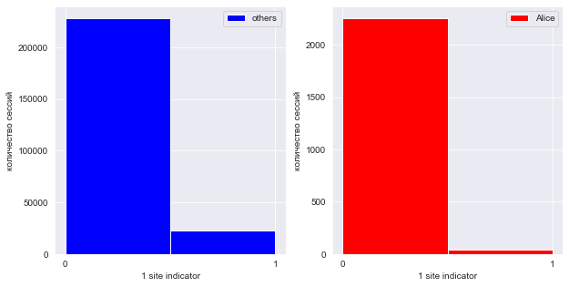

```python
hist_info(isWeekend[:253561],'1 site indicator',bins=2,xticks=[0,1],x_unique=[0,1])
```

```
mean others: 0.012
mean Alice: 0.005
```

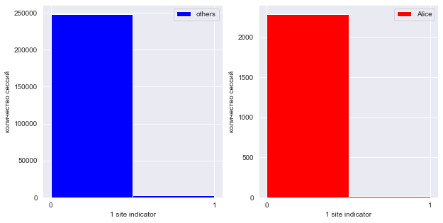

```python
hist_info(ind_top1[:253561],'1 site indicator',bins=2,xticks=[0,1],x_unique=[0,1])
```

```
mean others: 0.001
mean Alice: 0.008
```

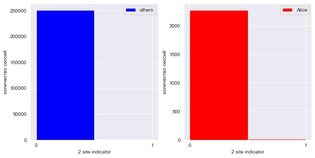

```python
hist_info(ind_top2[:253561],'2 site indicator',bins=2,xticks=[0,1],x_unique=[0,1])
```

Вычислим `год начала сессии`.

Здесь и далее будем сразу преобразовывать категориальные признаки с использованием dummies, в результате будем получать массивы индикаторных признаков.

```python
year = pd.to_datetime(train_test_df['time1']).apply(lambda x: x.year).values
added_fe_cat1 = pd.get_dummies(year)
added_fe_cat1.head()
```

|  | 2013 | 2014 |
| --- | --- | --- |
| 0 | 0 | 1 |
| 1 | 0 | 1 |
| 2 | 1 | 0 |
| 3 | 0 | 1 |
| 4 | 0 | 1 |

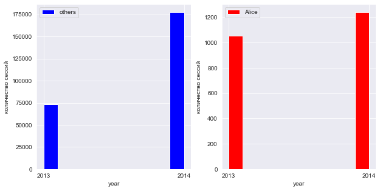

```python
hist_info(np.array(year[:253561],dtype=int),'year',xticks=[2013,2014],x_unique=[2013,2014],mean=False)
```

Найдем `месяц начала сессии`.

```python
month = pd.to_datetime(train_test_df['time1']).apply(lambda x: x.month).values
added_fe_cat2 = pd.get_dummies(month)
added_fe_cat2.head()
```

|  | 1 | 2 | 3 | 4 | 5 | 6 | 7 | 8 | 9 | 10 | 11 | 12 |
| --- | --- | --- | --- | --- | --- | --- | --- | --- | --- | --- | --- | --- |
| 0 | 0 | 1 | 0 | 0 | 0 | 0 | 0 | 0 | 0 | 0 | 0 | 0 |
| 1 | 0 | 1 | 0 | 0 | 0 | 0 | 0 | 0 | 0 | 0 | 0 | 0 |
| 2 | 0 | 0 | 0 | 0 | 0 | 0 | 0 | 0 | 0 | 0 | 0 | 1 |
| 3 | 0 | 0 | 1 | 0 | 0 | 0 | 0 | 0 | 0 | 0 | 0 | 0 |
| 4 | 0 | 1 | 0 | 0 | 0 | 0 | 0 | 0 | 0 | 0 | 0 | 0 |

```
mean others: 4.499
mean Alice: 5.894
```

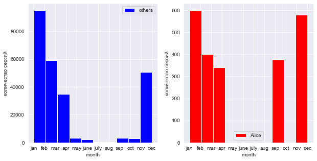

```python
m = ['jan','feb','mar','apr','may','june','july','aug','sep','oсt','nov','dec']
hist_info(month[:253561],'month',xticks=m,x_unique=range(1,13))
```

Найдем `час начала сессии`.

```python
start_hour =pd.to_datetime(train_test_df['time1']).apply(lambda x:x.time().hour).values
added_fe_cat3 = pd.get_dummies(start_hour)
added_fe_cat3.head()
```

|  | 7 | 8 | 9 | 10 | 11 | 12 | 13 | 14 | 15 | 16 | 17 | 18 | 19 | 20 | 21 | 22 | 23 |
| --- | --- | --- | --- | --- | --- | --- | --- | --- | --- | --- | --- | --- | --- | --- | --- | --- | --- |
| 0 | 0 | 0 | 0 | 1 | 0 | 0 | 0 | 0 | 0 | 0 | 0 | 0 | 0 | 0 | 0 | 0 | 0 |
| 1 | 0 | 0 | 0 | 0 | 1 | 0 | 0 | 0 | 0 | 0 | 0 | 0 | 0 | 0 | 0 | 0 | 0 |
| 2 | 0 | 0 | 0 | 0 | 0 | 0 | 0 | 0 | 0 | 1 | 0 | 0 | 0 | 0 | 0 | 0 | 0 |
| 3 | 0 | 0 | 0 | 1 | 0 | 0 | 0 | 0 | 0 | 0 | 0 | 0 | 0 | 0 | 0 | 0 | 0 |
| 4 | 0 | 0 | 0 | 1 | 0 | 0 | 0 | 0 | 0 | 0 | 0 | 0 | 0 | 0 | 0 | 0 | 0 |

```
mean others: 12.26
mean Alice: 15.434
```

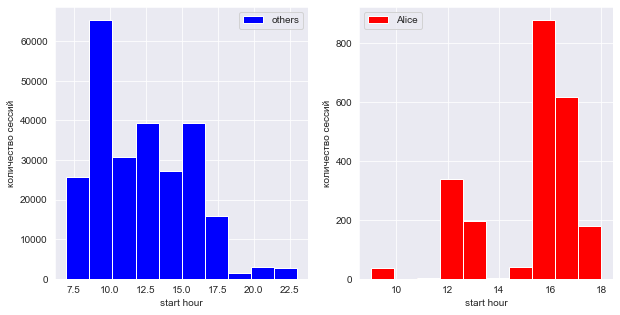

```python
hist_info(start_hour[:253561],'start hour')
```

Построим признак на основе `числа уникальных сайтов в сессии`.

```python
added_fe_cat4 = pd.get_dummies(unique_sites)
added_fe_cat4.head()
```

|  | 1 | 2 | 3 | 4 | 5 | 6 | 7 | 8 | 9 | 10 |
| --- | --- | --- | --- | --- | --- | --- | --- | --- | --- | --- |
| 0 | 0 | 1 | 0 | 0 | 0 | 0 | 0 | 0 | 0 | 0 |
| 1 | 0 | 0 | 0 | 0 | 0 | 0 | 1 | 0 | 0 | 0 |
| 2 | 0 | 0 | 0 | 1 | 0 | 0 | 0 | 0 | 0 | 0 |
| 3 | 1 | 0 | 0 | 0 | 0 | 0 | 0 | 0 | 0 | 0 |
| 4 | 0 | 0 | 0 | 1 | 0 | 0 | 0 | 0 | 0 | 0 |

```
mean others: 5.724
mean Alice: 6.126
```

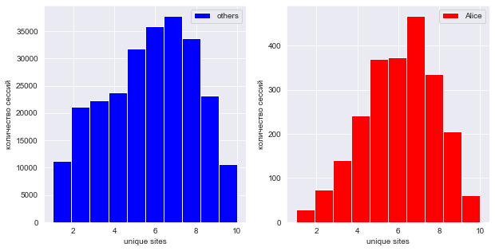

```python
hist_info(unique_sites[:253561],'unique sites')
```

Найдем `день недели, когда началась сессия`.

```python
day_of_week = pd.to_datetime(train_test_df['time1']).apply(lambda x:x.weekday()).values
added_fe_cat5 = pd.get_dummies(day_of_week)
added_fe_cat5.head()
```

|  | 0 | 1 | 2 | 3 | 4 | 5 | 6 |
| --- | --- | --- | --- | --- | --- | --- | --- |
| 0 | 0 | 0 | 0 | 1 | 0 | 0 | 0 |
| 1 | 0 | 0 | 0 | 0 | 0 | 1 | 0 |
| 2 | 1 | 0 | 0 | 0 | 0 | 0 | 0 |
| 3 | 0 | 0 | 0 | 0 | 1 | 0 | 0 |
| 4 | 0 | 0 | 0 | 0 | 1 | 0 | 0 |

```
mean others: 2.296
mean Alice: 1.585
```

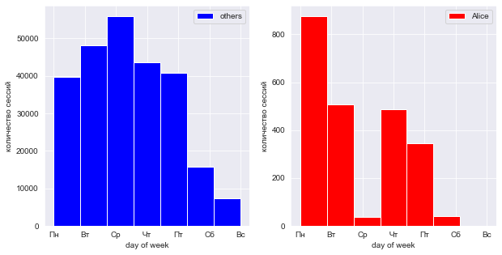

```python
dd=['Пн', 'Вт', 'Ср', 'Чт', 'Пт', 'Сб', 'Вс']
hist_info(day_of_week[:253561],'day of week',bins=7,xticks=dd,x_unique=range(7))
```

Найдем `время суток начала сессии`.

```python
TimeOfDay = pd.to_datetime(train_test_df['time1']).apply(lambda x:x.time().hour).apply(lambda x: 0 if x in range(7) else\
                                                                                      (1 if x in range(7,12) else \
                                                                                      (2 if x in range(12,18)\
                                                                                      else 3))).values
added_fe_cat6 = pd.get_dummies(TimeOfDay)
added_fe_cat6.head()
```

|  | 1 | 2 | 3 |
| --- | --- | --- | --- |
| 0 | 1 | 0 | 0 |
| 1 | 1 | 0 | 0 |
| 2 | 0 | 1 | 0 |
| 3 | 1 | 0 | 0 |
| 4 | 1 | 0 | 0 |

```
mean others: 1.559
mean Alice: 2.06
```

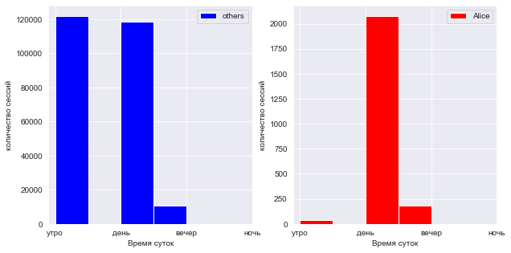

```python
ss=['утро','день','вечер','ночь']
hist_info(TimeOfDay[:253561],'Время суток',bins=4,xticks=ss,x_unique=range(1,5))
```

`Время года начала сессии.`

```python
season = pd.to_datetime(train_test_df['time1']).apply(lambda x: x.month).apply(lambda x: 1 if x in [12,1,2] else\
                                                                                      (2 if x in [3,4,5] else \
                                                                                      (3 if x in [6,7,8]\
                                                                                      else 4))).values

added_fe_cat7 = pd.get_dummies(season)
added_fe_cat7.head()
```

|  | 1 | 2 | 3 | 4 |
| --- | --- | --- | --- | --- |
| 0 | 1 | 0 | 0 | 0 |
| 1 | 1 | 0 | 0 | 0 |
| 2 | 1 | 0 | 0 | 0 |
| 3 | 0 | 1 | 0 | 0 |
| 4 | 1 | 0 | 0 | 0 |

```
mean others: 1.884
mean Alice: 2.397
```

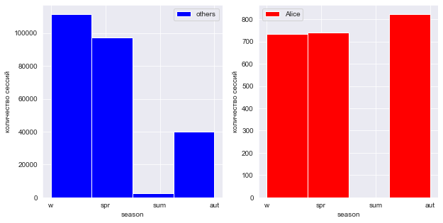

```python
ss=['w','spr','sum','aut']
hist_info(season[:253561],'season',bins=4,xticks=ss,x_unique=range(1,5))
```

Выделим из ранее построенной разреженной матрицы `частоты появления топ 5 сайтов словаря` (используем потом с Tfidf).

```python
added_fe_counts_top5 = train_test_sparse[:,:5].todense()
added_fe_counts_top5
```

```
matrix([[0, 0, 0, 0, 0],
        [0, 0, 0, 0, 0],
        [0, 0, 0, 0, 0],
        ...,
        [0, 0, 0, 0, 0],
        [0, 0, 0, 0, 0],
        [0, 0, 0, 0, 0]], dtype=int32)
```

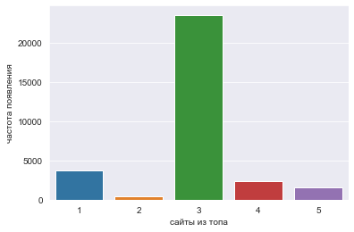

```python
sns.barplot(list(range(1,6)),np.array(sum(added_fe_counts_top5))[0])
plt.xlabel('сайты из топа')
plt.ylabel('частота появления');
```

Посмотрим на частоту появления в пределах класса

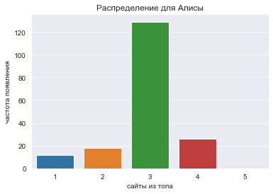

```python
df = pd.DataFrame(np.hstack([added_fe_counts_top5[:253561],y.values.reshape((253561,1))]),\
                  columns=['1','2','3','4','5','target'])
Alice_counts = np.array(sum(df[df.target==1].values[:,:-1]))

sns.barplot(list(range(1,6)),Alice_counts)
plt.xlabel('сайты из топа')
plt.ylabel('частота появления')
plt.title('Распределение для Алисы');
```

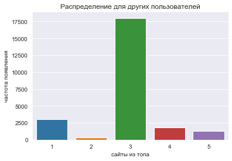

```python
other_counts = np.array(sum(df[df.target==0].values[:,:-1]))
sns.barplot(list(range(1,6)),other_counts)
plt.xlabel('сайты из топа')
plt.ylabel('частота появления')
plt.title('Распределение для других пользователей');
```

Видно отличие в распределениях для разных классов.

`Количество просмотренных сайтов в сессии`, а также `число сайтов в сессии из топ 10 словаря`.

```python
%%time
num_sites = np.zeros(sessions.shape[0],dtype=int)
num_sites_top10 = np.zeros(sessions.shape[0],dtype=int)

for i,session in enumerate(sessions):
    num_sites[i] = sum(session>0)
    for ID in range(1,11):
        if ID in session:
            num_sites_top10[i] += 1
added_fe_cat8 = pd.get_dummies(num_sites)
added_fe_cat8.head()
```

```
Wall time: 42.7 s
```

|  | 1 | 2 | 3 | 4 | 5 | 6 | 7 | 8 | 9 | 10 |
| --- | --- | --- | --- | --- | --- | --- | --- | --- | --- | --- |
| 0 | 1 | 0 | 0 | 0 | 0 | 0 | 0 | 0 | 0 | 0 |
| 1 | 0 | 0 | 0 | 0 | 0 | 0 | 0 | 0 | 0 | 1 |
| 2 | 0 | 0 | 0 | 0 | 0 | 0 | 0 | 0 | 0 | 1 |
| 3 | 0 | 0 | 0 | 0 | 0 | 0 | 0 | 0 | 0 | 1 |
| 4 | 0 | 0 | 0 | 0 | 0 | 0 | 0 | 0 | 0 | 1 |

```
mean others: 9.512
mean Alice: 9.912
```

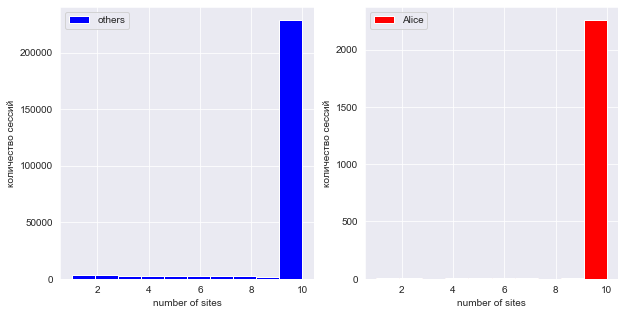

```python
hist_info(num_sites[:253561],'number of sites')
```

```python
added_fe_cat9 = pd.get_dummies(num_sites_top10)
added_fe_cat9.head()
```

|  | 0 | 1 | 2 | 3 | 4 | 5 | 6 | 7 |
| --- | --- | --- | --- | --- | --- | --- | --- | --- |
| 0 | 1 | 0 | 0 | 0 | 0 | 0 | 0 | 0 |
| 1 | 1 | 0 | 0 | 0 | 0 | 0 | 0 | 0 |
| 2 | 1 | 0 | 0 | 0 | 0 | 0 | 0 | 0 |
| 3 | 1 | 0 | 0 | 0 | 0 | 0 | 0 | 0 |
| 4 | 1 | 0 | 0 | 0 | 0 | 0 | 0 | 0 |

```
mean others: 1.493
mean Alice: 2.126
```

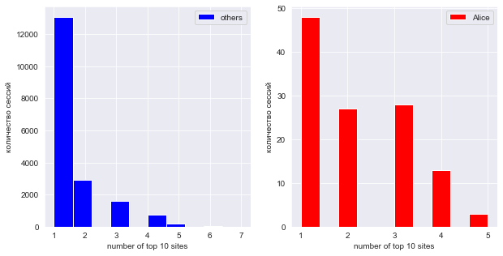

```python
hist_info(num_sites_top10[:253561],'number of top 10 sites',nonzero=True)
```

Далее построим признаки на основе длительности просмотра сайтов в сессии в секундах. Сначала создадим вспомогательный датафрейм session_times.

```python
%%time
train_test_df_time = train_test_df[['time%d' % i for i in range(1, 11)]]

tdf = train_test_df_time.fillna(0)
for i,col in tqdm_notebook(enumerate(tdf.columns)):
    tdf[f'sec{i+1}'] = pd.to_datetime(tdf[col]).apply(lambda x: x.timestamp())

session_times = tdf[['sec%d' % i for i in range(1, 11)]]
```

```
Wall time: 46.9 s
```

`Число просмотренных за 10 секунд сессии сайтов`.

```python
%%time
num_sites_10sec = np.zeros(session_times.shape[0],dtype=int)

for i,session in tqdm_notebook(enumerate(session_times.values)):
    num = 0
    j = 0
    duration = 0
    while (duration < 10) and (duration >= 0):
        num += 1
        j += 1
        if (j == session.shape[0]):
            break
        duration += session[j] - session[j-1]

    num_sites_10sec[i] = num

added_fe_cat10 = pd.get_dummies(num_sites_10sec)
added_fe_cat10.head()
```

```
Wall time: 6.73 s
```

|  | 1 | 2 | 3 | 4 | 5 | 6 | 7 | 8 | 9 | 10 |
| --- | --- | --- | --- | --- | --- | --- | --- | --- | --- | --- |
| 0 | 1 | 0 | 0 | 0 | 0 | 0 | 0 | 0 | 0 | 0 |
| 1 | 0 | 0 | 0 | 0 | 0 | 0 | 0 | 1 | 0 | 0 |
| 2 | 0 | 0 | 0 | 0 | 0 | 0 | 0 | 0 | 0 | 1 |
| 3 | 1 | 0 | 0 | 0 | 0 | 0 | 0 | 0 | 0 | 0 |
| 4 | 1 | 0 | 0 | 0 | 0 | 0 | 0 | 0 | 0 | 0 |

```
mean others: 5.357
mean Alice: 6.869
```

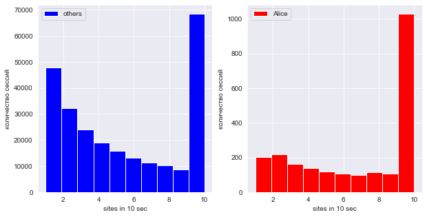

```python
hist_info(num_sites_10sec[:253561],'sites in 10 sec')
```

Непосредственно сами `длительности просмотра сайтов в сессии`.

```python
%%time
for ind, col in enumerate(session_times.columns):
    if ind > 0:
        session_times[f'dur{ind}'] =  session_times[col] - session_times[session_times.columns[ind-1]]

durations = session_times[[f'dur{i}' for i in range(1,10)]]
dur_array = np.array(durations,dtype = float)
for i,session in enumerate(dur_array):
    for j,dur in enumerate(session):
        if dur < 0:
            if j==0:
                dur_array[i,j]=30*60
            else:
                dur_array[i,j]=30*60 - sum(session[:j])
pd.DataFrame(dur_array).head()
```

```
Wall time: 5.58 s
```

|  | 0 | 1 | 2 | 3 | 4 | 5 | 6 | 7 | 8 |
| --- | --- | --- | --- | --- | --- | --- | --- | --- | --- |
| 0 | 1800.0 | 0.0 | 0.0 | 0.0 | 0.0 | 0.0 | 0.0 | 0.0 | 0.0 |
| 1 | 0.0 | 1.0 | 0.0 | 0.0 | 0.0 | 1.0 | 0.0 | 23.0 | 1.0 |
| 2 | 1.0 | 1.0 | 0.0 | 0.0 | 0.0 | 1.0 | 1.0 | 1.0 | 2.0 |
| 3 | 30.0 | 30.0 | 30.0 | 30.0 | 30.0 | 30.0 | 30.0 | 30.0 | 30.0 |
| 4 | 137.0 | 0.0 | 1.0 | 0.0 | 36.0 | 0.0 | 0.0 | 67.0 | 5.0 |

Для качественной работы SGD отмасштабируем длительности просмотра.

```python
scaler = StandardScaler().fit(dur_array)
time_fe_to_add= scaler.transform(dur_array)
time_fe_to_add
```

```
array([[ 7.43082048e+00, -1.86990210e-01, -1.77756240e-01, ...,
        -1.64688560e-01, -1.63647797e-01, -1.62573577e-01],
       [-1.92170448e-01, -1.82398417e-01, -1.77756240e-01, ...,
        -1.64688560e-01, -5.31634573e-03, -1.55492496e-01],
       [-1.87935453e-01, -1.82398417e-01, -1.77756240e-01, ...,
        -1.57804765e-01, -1.56763821e-01, -1.48411414e-01],
       ...,
       [-1.92170448e-01, -1.86990210e-01, -1.40489900e-01, ...,
        -1.57804765e-01, -1.63647797e-01, -1.62573577e-01],
       [-1.83700458e-01, -1.86990210e-01, -1.77756240e-01, ...,
        -1.57804765e-01, -1.63647797e-01, -1.62573577e-01],
       [-1.92170448e-01, -1.82398417e-01, -1.03223559e-01, ...,
        -1.44037176e-01,  1.56763044e-03, -1.27168169e-01]])
```

```
mean others: 1.598
mean Alice: 0.965
```

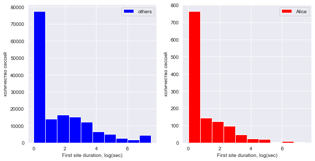

```python
hist_info(dur_array[:253561,0],'First site duration, log(sec)',bins=10,nonzero=True,log=True)
```

*Построим тренировочную и тестовую выборки из новых признаков.*

```python
X_add_train =  np.hstack((added_fe1[:253561],\
                          added_fe_cat1.values[:253561],added_fe_cat2.values[:253561],\
                          added_fe_cat3.values[:253561],added_fe_cat4.values[:253561],\
                          added_fe_cat5.values[:253561],added_fe_cat6.values[:253561],\
                          added_fe_cat7.values[:253561],\
                          added_fe_counts_top5[:253561],\
                          added_fe_cat8.values[:253561],added_fe_cat9.values[:253561],added_fe_cat10.values[:253561],\
                          time_fe_to_add[:253561]))

X_add_test =  np.hstack((added_fe1[253561:],\
                         added_fe_cat1.values[253561:],added_fe_cat2.values[253561:],\
                         added_fe_cat3.values[253561:],added_fe_cat4.values[253561:],\
                         added_fe_cat5.values[253561:],added_fe_cat6.values[253561:],\
                         added_fe_cat7.values[253561:],\
                         added_fe_counts_top5[253561:],\
                         added_fe_cat8.values[253561:],added_fe_cat9.values[253561:],added_fe_cat10.values[253561:],\
                         time_fe_to_add[253561:]))
```

```python
X_add_train.shape
```

```
(253561, 100)
```

Видно, что имеем 100 дополнительных столбцов признаков.

#### Проверим несколько гипотез о данных.

**1.** Проверим, зависит ли индикатор начала сессии в выходной день от пользователя. Признак бинарный, имеем распределение Бернулли.

```python
df_weekend = pd.DataFrame(np.vstack([isWeekend[:253561],y]).T,columns=['isWeekend','target'])
df_weekend.head()
```

|  | isWeekend | target |
| --- | --- | --- |
| 0 | 0 | 0 |
| 1 | 1 | 0 |
| 2 | 0 | 0 |
| 3 | 0 | 0 |
| 4 | 0 | 0 |

```python
weekend_Alice = df_weekend[df_weekend.target == 1].isWeekend
weekend_others = df_weekend[df_weekend.target == 0].isWeekend
```

```python
conf_interval_weekend_Alice= proportion_confint(sum(weekend_Alice),
                                           weekend_Alice.shape[0],
                                            method = 'wilson')
conf_interval_weekend_others = proportion_confint(sum(weekend_others),
                                            weekend_others.shape[0],
                                            method = 'wilson')
print('95%% confidence interval for a probability of weekend session for Alice [%f, %f]' % conf_interval_weekend_Alice)
print('95%% confidence interval for a probability of weekend session for others [%f, %f]' % conf_interval_weekend_others)
```

```
95% confidence interval for a probability of weekend session for Alice [0.013556, 0.024622]
95% confidence interval for a probability of weekend session for others [0.090769, 0.093026]
```

Доверительные интервалы не пересекаются, при этом вероятность для Алисы существенно меньше.

Оценим доверительный интервал для разности вероятностей и достигаемый уровень значимости. Для этого применим соответствующие функции.

```python
def proportions_diff_confint_ind(sample1, sample2, alpha = 0.05):
    z = scipy.stats.norm.ppf(1 - alpha / 2.)

    p1 = float(sum(sample1)) / len(sample1)
    p2 = float(sum(sample2)) / len(sample2)

    left_boundary = (p1 - p2) - z * np.sqrt(p1 * (1 - p1)/ len(sample1) + p2 * (1 - p2)/ len(sample2))
    right_boundary = (p1 - p2) + z * np.sqrt(p1 * (1 - p1)/ len(sample1) + p2 * (1 - p2)/ len(sample2))

    return (left_boundary, right_boundary)

def proportions_diff_z_stat_ind(sample1, sample2):
    n1 = len(sample1)
    n2 = len(sample2)

    p1 = float(sum(sample1)) / n1
    p2 = float(sum(sample2)) / n2
    P = float(p1*n1 + p2*n2) / (n1 + n2)

    return (p1 - p2) / np.sqrt(P * (1 - P) * (1. / n1 + 1. / n2))

def proportions_diff_z_test(z_stat, alternative = 'two-sided'):
    if alternative not in ('two-sided', 'less', 'greater'):
        raise ValueError("alternative not recognized\n"
                         "should be 'two-sided', 'less' or 'greater'")

    if alternative == 'two-sided':
        return 2 * (1 - scipy.stats.norm.cdf(np.abs(z_stat)))

    if alternative == 'less':
        return scipy.stats.norm.cdf(z_stat)

    if alternative == 'greater':
        return 1 - scipy.stats.norm.cdf(z_stat)
```

```python
print("95%% confidence interval for a difference between proportions: [%f, %f]" %\
      proportions_diff_confint_ind(weekend_Alice, weekend_others))
print("p-value: %f" % proportions_diff_z_test(proportions_diff_z_stat_ind(weekend_Alice, weekend_others)))
```

```
95% confidence interval for a difference between proportions: [-0.079201, -0.068012]
p-value: 0.000000
```

Итак, гипотеза о независимости отвергается в пользу двусторонней альтернативы, с большим запасом по p-value.

**2.** Проверим, зависит ли вероятность появления 1-го сайта из словаря в сессии от пользователя. Признак индикторный, а значит - бинарный, имеем распределение Бернулли, при это вероятности очень малы. В связи с этим рассмотрим только доверительные интервалы Уилсона.

```python
df_top1 = pd.DataFrame(np.vstack([ind_top1[:253561],y]).T,columns=['ind_top1','target'])
top1_Alice = df_top1[df_top1.target == 1].ind_top1
top1_others = df_top1[df_top1.target == 0].ind_top1
conf_interval_top1_Alice= proportion_confint(sum(top1_Alice),
                                           top1_Alice.shape[0],
                                            method = 'wilson')
conf_interval_top1_others = proportion_confint(sum(top1_others),
                                            top1_others.shape[0],
                                            method = 'wilson')
print('95%% confidence interval for a probability of 1st site visit for Alice [%f, %f]' % conf_interval_top1_Alice)
print('95%% confidence interval for a probability of 1st site visit  for others [%f, %f]' % conf_interval_top1_others)
```

```
95% confidence interval for a probability of 1st site visit for Alice [0.002991, 0.009110]
95% confidence interval for a probability of 1st site visit  for others [0.011412, 0.012251]
```

Видно, что интервалы не пересакаются, для Алисы она существенно меньше, можно сделать вывод, что зависимость от класса для этого признака также проявляется.

**3.** Проверим, зависит ли вероятность появления 2-го сайта из словаря в сессии от пользователя.

```python
df_top2 = pd.DataFrame(np.vstack([ind_top2[:253561],y]).T,columns=['ind_top2','target'])
top2_Alice = df_top2[df_top1.target == 1].ind_top2
top2_others = df_top2[df_top1.target == 0].ind_top2
conf_interval_top2_Alice= proportion_confint(sum(top2_Alice),
                                           top2_Alice.shape[0],
                                            method = 'wilson')
conf_interval_top2_others = proportion_confint(sum(top2_others),
                                            top2_others.shape[0],
                                            method = 'wilson')
print('95%% confidence interval for a probability of 2nd site visit for Alice [%f, %f]' % conf_interval_top2_Alice)
print('95%% confidence interval for a probability of 2nd site visit  for others [%f, %f]' % conf_interval_top2_others)
```

```
95% confidence interval for a probability of 2nd site visit for Alice [0.004963, 0.012353]
95% confidence interval for a probability of 2nd site visit  for others [0.001055, 0.001300]
```

Здесь зависимость также видна, при этом вероятность для Алисы несколько больше.

**4.** Проверим, зависит ли год начала сессии от пользователя. Для этого нужно будет немного преобразовать признаки.

```python
df_year = pd.DataFrame(np.vstack([year[:253561],y]).T,columns=['year','target'])
df_year.year = df_year.year.apply(lambda x: 1 if x==2014 else 0)
year_Alice = df_year[df_year.target == 1].year
year_others = df_year[df_year.target == 0].year

print("95%% confidence interval for a difference between proportions: [%f, %f]" %\
      proportions_diff_confint_ind(year_Alice, year_others))
print("p-value: %f" % proportions_diff_z_test(proportions_diff_z_stat_ind(year_Alice, year_others)))
```

```
95% confidence interval for a difference between proportions: [-0.187194, -0.146277]
p-value: 0.000000
```

Зависимость от класса явная.

**5.** Проверим, значимы ли со статистической точки зрения различия между распределениями месяца нечала сессии. Для этого используем критерий Уилкоксона-Манна-Уитни.

```python
df_month = pd.DataFrame(np.vstack([month[:253561],y]).T,columns=['month','target'])
month_Alice = df_month[df_month.target == 1].month
month_others = df_month[df_month.target == 0].month
stats.mannwhitneyu(month_Alice, month_others)
```

```
MannwhitneyuResult(statistic=231855243.5, pvalue=1.1486580063071092e-61)
```

Нулевая гипотеза о равенстве распределений уверенно отвергается в пользу альтернативы.

**6.** Проверим, значимы ли со статистической точки зрения различия между распределениями часа начала сессии. Для этого также используем критерий Уилкоксона-Манна-Уитни.

```python
df_hour = pd.DataFrame(np.vstack([start_hour[:253561],y]).T,columns=['hour','target'])
hour_Alice = df_hour[df_hour.target == 1].hour
hour_others = df_hour[df_hour.target == 0].hour

stats.mannwhitneyu(hour_Alice, hour_others)
```

```
MannwhitneyuResult(statistic=112097587.0, pvalue=0.0)
```

Нулевая гипотеза о равенстве распределений уверенно отвергается в пользу альтернативы.

**7.** Проверим, значимы ли со статистической точки зрения различия средними значениями числа уникальных сайтов. Для этого сначала проведем тест на нормальность.

```python
df_unique_sites = pd.DataFrame(np.vstack([unique_sites[:253561],y]).T,columns=['unique_sites','target'])
unique_sites_Alice = df_unique_sites[df_unique_sites.target == 1].unique_sites
unique_sites_others = df_unique_sites[df_unique_sites.target == 0].unique_sites
```

```
Alice
```

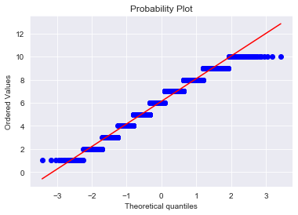

```
Shapiro-Wilk normality test, W-statistic: 0.966290, p-value: 0.000000
```

```python
print('Alice')
stats.probplot(unique_sites_Alice, plot=plt)
plt.show()
print("Shapiro-Wilk normality test, W-statistic: %f, p-value: %f" % stats.shapiro(unique_sites_Alice))
```

```
Others
```

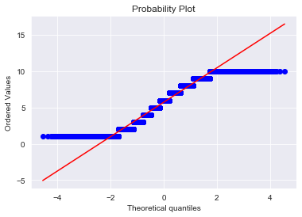

```
Shapiro-Wilk normality test, W-statistic: 0.958355, p-value: 0.000000
```

```python
print('Others')
stats.probplot(unique_sites_others, plot=plt)
plt.show()
print("Shapiro-Wilk normality test, W-statistic: %f, p-value: %f" % stats.shapiro(unique_sites_others))
```

Видно, что распределения не являются нормальными, но всё же попробуем применить критерий Стьюдента для разности средних значений (он не очень чувствителен к отклонениям от нормальности, а на QQ графике и гистограммах видно, что распределения напоминают нормальное), чтобы определить, статистически значимы ли отличия. Также отмечу, что попробовать применить данный критерий можно еще и на основании центральной предельной теоремы, поскольку данных много, а распределения не являются скошенными. Для чистоты эксперимента нужно, конечно, еще проверить, распределены ли выборочные дисперсии по хи квадрат, но этого делать не будет. Сравним доверительные интервалы, полученными разными методами, для проверки.

Критерий Стьюдента для независимых выборок выполняется корректно, если у большей выборки большая десперсия.

```python
unique_sites_others.std(),unique_sites_Alice.std()
```

```
(2.4246502001571337, 1.9898902831795806)
```

Данное условие выполняется, применим критерий.

```python
scipy.stats.ttest_ind(unique_sites_others, unique_sites_Alice, equal_var = False)
```

```
Ttest_indResult(statistic=-9.634877347987135, pvalue=1.4140627960648278e-21)
```

Видно, что данный критерий отвергает гипотезу о равенстве средних.

Построим доверительный интервал для средних. Воспользуемся t-интервалом, а также сравним его с интервалом, полученным с помощью бутстрапа.

t-интервал:

```python
Alice_mean_std = unique_sites_Alice.std(ddof=1)/np.sqrt(unique_sites_Alice.shape[0])
Others_mean_std = unique_sites_others.std(ddof=1)/np.sqrt(unique_sites_others.shape[0])
Alice_mean = unique_sites_Alice.mean()
Others_mean = unique_sites_others.mean()
```

```python
print("Alice mean 95% confidence interval", _tconfint_generic(Alice_mean, Alice_mean_std,
                                                                       unique_sites_Alice.shape[0] - 1,
                                                                       0.05, 'two-sided'))

print("Others mean 95% confidence interval", _tconfint_generic(Others_mean, Others_mean_std,
                                                                       unique_sites_others.shape[0] - 1,
                                                                       0.05, 'two-sided'))
```

```
Alice mean 95% confidence interval (6.044832639552108, 6.207670625576321)
Others mean 95% confidence interval (5.714033350379583, 5.732994476925563)
```

Бутстрап:

```python
def get_bootstrap_samples(data, n_samples):
    indices = np.random.randint(0, len(data), (n_samples, len(data)))
    samples = data[indices]
    return samples

def stat_intervals(stat, alpha):
    boundaries = np.percentile(stat, [100 * alpha / 2., 100 * (1 - alpha / 2.)])
    return boundaries
```

```python
np.random.seed(0)

Alice_mean_scores = list(map(np.mean, get_bootstrap_samples(unique_sites_Alice.values, 1000)))
Others_mean_scores = list(map(np.mean, get_bootstrap_samples(unique_sites_others.values, 1000)))

print("95% confidence interval for unique sites of Alice:",  stat_intervals(Alice_mean_scores, 0.05))
print("95% confidence interval for unique sites of others:",  stat_intervals(Others_mean_scores, 0.05))
```

```
95% confidence interval for unique sites of Alice: [6.04350239 6.20635612]
95% confidence interval for unique sites of others: [5.71376719 5.73256625]
```

Интервалы практически идентичны, что понятно, поскольку центральная предельная теорема работает. Интервалы не пересекаются, поэтому результаты t теста подтверждены.

**8.** Проверим статистическую значимость в отличиях распределений для разных классов для остальных признаков. Воспользуемся снова критерием Уилкоксона-Манна-Уитни. Определим функцию для расчета.

```python
def diff_dcheck(col,f_name='feat'):
    df = pd.DataFrame(np.vstack([col[:253561],y]).T,columns=[f_name,'target'])
    Alice = df[df.target == 1][f_name]
    others = df[df.target == 0][f_name]

    return stats.mannwhitneyu(Alice, others)
```

День недели начала сессии

```python
diff_dcheck(day_of_week)
```

```
MannwhitneyuResult(statistic=216565964.5, pvalue=8.350180434943464e-98)
```

Отличия между распределениями значимы.

Время года сессии

```python
diff_dcheck(season)
```

```
MannwhitneyuResult(statistic=227321555.0, pvalue=6.8706364777907145e-81)
```

Отличия между распределениями значимы.

```python
print('TimeOfDay: ',diff_dcheck(TimeOfDay))
print('num_sites_top10: ',diff_dcheck(num_sites_top10))
print('num_sites_10sec: ',diff_dcheck(num_sites_10sec))
print('dur_array: ',diff_dcheck(dur_array[:,0]))
```

```
TimeOfDay:  MannwhitneyuResult(statistic=154538492.0, pvalue=0.0)
num_sites_top10:  MannwhitneyuResult(statistic=282604982.0, pvalue=7.85605241293872e-05)
num_sites_10sec:  MannwhitneyuResult(statistic=219148054.5, pvalue=4.7714252639978955e-91)
dur_array:  MannwhitneyuResult(statistic=247558821.0, pvalue=1.8762536533123872e-34)
```

Отличия в распределениях и по этим признакам значимы.

**9.** Проверим степень корреляции признаков месяц и сезон.

Попробуем воспользоваться критерием хи квадрат, поскольку данные признаки категориальные.

```python
cross = pd.crosstab(month, season)
cross
```

| col_0 row_0 | 1 | 2 | 3 | 4 |
| --- | --- | --- | --- | --- |
| 1 | 36232 | 0 | 0 | 0 |
| 2 | 59492 | 0 | 0 | 0 |
| 3 | 0 | 59587 | 0 | 0 |
| 4 | 0 | 35201 | 0 | 0 |
| 5 | 0 | 28909 | 0 | 0 |
| 6 | 0 | 0 | 6459 | 0 |
| 7 | 0 | 0 | 10976 | 0 |
| 8 | 0 | 0 | 8136 | 0 |
| 9 | 0 | 0 | 0 | 7091 |
| 10 | 0 | 0 | 0 | 10945 |
| 11 | 0 | 0 | 0 | 44390 |
| 12 | 28940 | 0 | 0 | 0 |

```python
chi2_stats = stats.chi2_contingency(cross)
chi2_stats
```

```
(1009074.0000000001,
 0.0,
 33,
 array([[13428.62678456, 13324.46293532,  2754.47134303,  6724.43893708],
        [22049.45530655, 21878.42098003,  4522.77017939, 11041.35353403],
        [22084.66505331, 21913.35761005,  4529.99238014, 11058.9849565 ],
        [13046.50837501, 12945.30856112,  2676.0914591 ,  6533.09160478],
        [10714.51125289, 10631.40039184,  2197.75369993,  5365.33465534],
        [ 2393.89215063,  2375.32308731,   491.03362786,  1198.75113421],
        [ 4068.02295174,  4036.46790622,   834.43026775,  2037.07887429],
        [ 3015.43683813,  2992.04654564,   618.5244769 ,  1509.99213933],
        [ 2628.12962379,  2607.74361543,   539.08026864,  1316.04649213],
        [ 4056.53345543,  4025.06753221,   832.07354961,  2031.32546275],
        [16452.21745878, 16324.60006897,  3374.66832958,  8238.51414267],
        [10726.0007492 , 10642.80076585,  2200.11041807,  5371.08806688]]))
```

Хотя в исходной матрице много нулевых ячеек, ожидаемые частоты в каждой ячейке намного больше 5, критерий применим.

Найдем v Крамера.

```python
phi_c = np.sqrt(chi2_stats[0]/(sum(sum(cross.values))*(np.min([cross.shape[0],cross.shape[1]])-1)))
phi_c
```

```
1.0
```

Вышеуказанные величины зависимы, несут идентичную информацию.

Аналогично, рассмотрим час и время суток:

```python
cross2 = pd.crosstab(start_hour, TimeOfDay)
cross2
```

| col_0 row_0 | 1 | 2 | 3 |
| --- | --- | --- | --- |
| 7 | 600 | 0 | 0 |
| 8 | 31666 | 0 | 0 |
| 9 | 40911 | 0 | 0 |
| 10 | 44790 | 0 | 0 |
| 11 | 41475 | 0 | 0 |
| 12 | 0 | 22607 | 0 |
| 13 | 0 | 30392 | 0 |
| 14 | 0 | 36903 | 0 |
| 15 | 0 | 29076 | 0 |
| 16 | 0 | 25002 | 0 |
| 17 | 0 | 17638 | 0 |
| 18 | 0 | 0 | 5789 |
| 19 | 0 | 0 | 2307 |
| 20 | 0 | 0 | 1793 |
| 21 | 0 | 0 | 2129 |
| 22 | 0 | 0 | 1757 |
| 23 | 0 | 0 | 1523 |

```python
chi2_stats2 = stats.chi2_contingency(cross2)
chi2_stats2
```

```
(672716.0, 0.0, 32, array([[  284.41481992,   288.29639848,    27.2887816 ],
        [15010.46614619, 15215.32292379,  1440.21093002],
        [19392.82449652, 19657.48993037,  1860.68557311],
        [21231.56630733, 21521.32614655,  2037.10754613],
        [19660.17442725, 19928.48854494,  1886.33702781],
        [10716.27639004, 10862.52780074,  1028.19580923],
        [14406.55867855, 14603.17357102,  1382.26775043],
        [17492.93349943, 17731.66998852,  1678.39651205],
        [13782.74217352, 13970.84347035,  1322.41435613],
        [11851.56554623, 12013.31092467,  1137.1235291 ],
        [ 8360.84765637,  8474.95312732,   802.19921631],
        [ 2744.12898757,  2781.57975134,   263.2912611 ],
        [ 1093.57498261,  1108.49965216,   104.92536524],
        [  849.92628687,   861.52573746,    81.54797567],
        [ 1009.19858603,  1022.97172061,    96.82969336],
        [  832.86139768,   844.22795355,    79.91064877],
        [  721.93961791,   731.79235814,    69.26802395]]))
```

```python
phi_c2 = np.sqrt(chi2_stats2[0]/(np.sum(cross2.values)*(np.min([cross2.shape[0],cross2.shape[1]])-1)))
phi_c2
```

```
1.0
```

Вышеуказанные величины также зависимы, несут идентичную информацию.

Проверим корреляцию Пирсона вещественных признаков (время просмотра сайта).

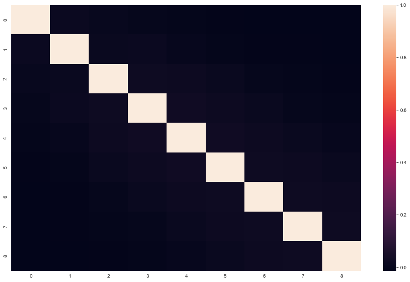

```python
corr_martix = pd.DataFrame(time_fe_to_add).corr()
plt.figure(figsize=(16,10))
sns.heatmap(corr_martix);
```

Видно, что корреляции нет.

**Итак, построенные признаки имеют различные распределения для разных классов, что может помочь в классификации объектов. При этом небольшая часть категориальных признаков коррелируют, даже практически совпадают, имеется опция удалить некоторые из них.**

### 4. Построение алгоритма классификации, предсказание классов для тестовых данных соревнования

Подготовим данные для обучения и тестирования. *Для этого добавим к разреженным матрицам новые признаки.*

```python
X = csr_matrix(hstack([X_train_sparse,X_add_train]))
X_test =csr_matrix(hstack([X_test_sparse,X_add_test]))
```

Далее *разделим данные на обучение и валидацию.*

```python
train_share = int(.7 * X.shape[0])
X_train, y_train = X[:train_share, :], y[:train_share]
X_valid, y_valid  = X[train_share:, :], y[train_share:]
```

`В данной части проекта за основу берется SGD логистическая регрессия, поскольку данный тип алгоритмов показал себя хорошо в соревновании. Далее будут вкратце описаны шаги, которые проделаны ранее в рамках соревнования.`

**1.** Подберем по сетке оптимальный классификатор SGDClassifier.

Сначала зададим стратегию кроссвалидации.

```python
skf = StratifiedKFold(n_splits=3, shuffle=False, random_state=17)
```

Получим бейзлайн

```python
%%time
sgd_logit = SGDClassifier(loss='log',random_state=17,n_jobs=-1)
sgd_logit.fit(X_train, y_train)
logit_valid_pred_proba = sgd_logit.predict_proba(X_valid)
ROC_AUC_logit = roc_auc_score(y_valid,logit_valid_pred_proba[:,1])
print(round(ROC_AUC_logit,3))
```

```
0.954
Wall time: 1.19 s
```

Подбор параметров по сетке

```python
%%time
param_grid_SGD = {'alpha':[0.00005,0.0005,0.005],
                  'learning_rate': ['optimal','invscaling','adaptive'],
                  'eta0':[0.01,0.1,1],
                  'class_weight': ['balanced',{1:50,0:1},{1:40,0:1},{1:30,0:1},None]}
sgd_clf = SGDClassifier(loss='log',n_jobs=-1,random_state=17)

sgd_grid_searcher = GridSearchCV(sgd_clf,param_grid_SGD,cv=skf,n_jobs=-1,scoring='roc_auc')
sgd_grid_searcher.fit(X_train, y_train)
print(f'best score: {sgd_grid_searcher.best_score_}')
print(f'best parameters: {sgd_grid_searcher.best_params_}')
```

```
best score: 0.9865840265221261
best parameters: {'alpha': 5e-05, 'class_weight': {1: 50, 0: 1}, 'eta0': 0.1, 'learning_rate': 'adaptive'}
Wall time: 8min 2s
```

Попробуем более тонкую настройку параметра alpha и весов классов,также попробуем подобрать l1_ration для Elastic net регуляризации

```python
%%time
param_grid_SGD2 = {'alpha':[0.00001,0.00003,0.00005,0.00007],
                  'l1_ratio':[0,0.1,0.15,0.5],
                  'class_weight':[{1: 80, 0: 1},{1: 70, 0: 1},{1: 60, 0: 1},{1: 50, 0: 1}]}
sgd_clf2 = SGDClassifier(loss='log',random_state=17,learning_rate = 'adaptive',eta0=0.1)

sgd_grid_searcher2 = GridSearchCV(sgd_clf2,param_grid_SGD2,cv=skf,n_jobs=-1,scoring='roc_auc')
sgd_grid_searcher2.fit(X_train, y_train)
print(f'best score: {sgd_grid_searcher2.best_score_}')
print(f'best parameters: {sgd_grid_searcher2.best_params_}')
```

```
best score: 0.9870770363448623
best parameters: {'alpha': 3e-05, 'class_weight': {1: 50, 0: 1}, 'l1_ratio': 0}
Wall time: 7min 19s
```

Построим валидационную кривую зависимости качества алгоритма от параметра alpha, который влияет на регуляризацию.

```python
def plot_validation_curves(param_values, grid_cv_results_):
    train_mu, train_std = grid_cv_results_['mean_train_score'], grid_cv_results_['std_train_score']
    valid_mu, valid_std = grid_cv_results_['mean_test_score'], grid_cv_results_['std_test_score']
    train_line = plt.plot(param_values, train_mu, '-', label='train', color='green')
    valid_line = plt.plot(param_values, valid_mu, '-', label='test', color='red')
    plt.fill_between(param_values, train_mu - train_std, train_mu + train_std, edgecolor='none',
                     facecolor=train_line[0].get_color(), alpha=0.2)
    plt.fill_between(param_values, valid_mu - valid_std, valid_mu + valid_std, edgecolor='none',
                     facecolor=valid_line[0].get_color(), alpha=0.2)
    plt.legend()
```

```
Wall time: 1min 27s
```

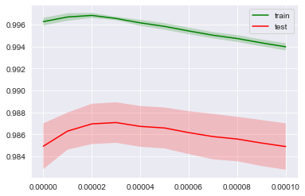

```python
%%time
param_grid_SGD3 = {'alpha':np.linspace(0,10,11)*1e-5}
sgd_clf3 = SGDClassifier(loss='log',class_weight={1: 50, 0: 1},l1_ratio=0,random_state=17,\
                         learning_rate = 'adaptive',eta0=0.1)
sgd_grid_searcher3 = GridSearchCV(sgd_clf3,param_grid_SGD3,cv=skf,n_jobs=-1,\
                                  scoring='roc_auc',return_train_score=True)
sgd_grid_searcher3.fit(X_train, y_train)
plot_validation_curves(np.linspace(0,10,11)*1e-5, sgd_grid_searcher3.cv_results_)
```

Видно, что подобранный выше параметр является наилучшим.

Построим кривую обучения для того, чтобы посмотреть, как влияет размер обучающей выборки на качества алгоритма.

```python
def plot_learning_curve(val_train, val_test, train_sizes,
                        xlabel='Training Set Size', ylabel='score'):
    def plot_with_err(x, data, **kwargs):
        mu, std = data.mean(1), data.std(1)
        lines = plt.plot(x, mu, '-', **kwargs)
        plt.fill_between(x, mu - std, mu + std, edgecolor='none',
                         facecolor=lines[0].get_color(), alpha=0.2)
    plot_with_err(train_sizes, val_train, label='train')
    plot_with_err(train_sizes, val_test, label='valid')
    plt.xlabel(xlabel); plt.ylabel(ylabel)
    plt.legend(loc='lower right');
```

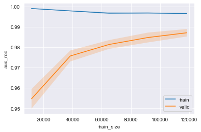

```python
sgd_clf4 = SGDClassifier(loss='log',alpha = 3e-05,class_weight={1: 50, 0: 1},l1_ratio=0,\
                         random_state=17,learning_rate = 'adaptive',eta0=0.1)
n_train,val_train, val_test= learning_curve(sgd_clf4, X_train, y_train,cv=skf,scoring='roc_auc',random_state=17,n_jobs=-1)
plot_learning_curve(val_train, val_test, n_train, xlabel='train_size', ylabel='auc_roc')
```

Анализируя кривую обучения, можно заметить, что для улучшения качества можно добавить еще данных. Это и произойдет, когда обучение будет происходить на всей выборке.

Проверим качество подобранного алгоритма на валидационной выборке.

```python
%%time
sgd_clf4.fit(X_train, y_train)
sgd_clf4_valid_pred_proba = sgd_clf4.predict_proba(X_valid)
ROC_AUC_sgd_clf4 = roc_auc_score(y_valid,sgd_clf4_valid_pred_proba[:,1])
print(round(ROC_AUC_sgd_clf4,3))
```

```
0.988
Wall time: 7.63 s
```

Видно, что качество значительно лучше, чем у бейзлайна.

*Проверим теперь качество в соревновании.*

```python
def write_to_submission_file(predicted_labels, out_file,
                             target='target', index_label="session_id"):
    # turn predictions into data frame and save as csv file
    predicted_df = pd.DataFrame(predicted_labels,
                                index = np.arange(1, predicted_labels.shape[0] + 1),
                                columns=[target])
    predicted_df.to_csv(out_file, index_label=index_label)
```

```python
%%time
sgd_clf4.fit(X,y)
sgd_clf4_valid_pred_proba = sgd_clf4.predict_proba(X_test)
sgd_clf4_valid_pred_proba[:,1]
```

```
Wall time: 12.1 s
```

```
array([2.24152768e-05, 2.87783722e-06, 5.21565340e-06, ...,
       3.52215852e-04, 8.55800259e-09, 3.21157040e-09])
```

```python
write_to_submission_file(sgd_clf4_valid_pred_proba[:,1],out_file='submission1.csv')
```

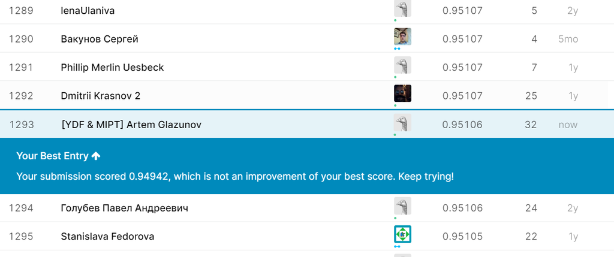

Видно, что качество данного алгоритма на данных соревнования 0.94942.

**2.** Улучшение качества в соревновании

Попробуем улучшить качество, смешав ответы от разных алгоритмов. Будем использовать дополнительно `градиентный бустинг и случайный лес`. Оптимальные параметры для вышеуказанных алгоритмов уже подобраны предварительно в рамках выполнения проекта. Посмотрим на алгоритмы и обучим их на данных соревнования.

```python
%%time
gb_clf = xgb.XGBClassifier(learning_rate=0.5,max_depth=7, min_child_weight=1, random_state=17,n_estimators=100)
gb_clf.fit(X,y)
gb_test_pred_proba = gb_clf.predict_proba(X_test)
gb_test_pred_proba[:,1]
```

```
Wall time: 4min 34s
```

```
array([7.1680479e-06, 4.0890718e-06, 5.6849771e-05, ..., 2.9966499e-05,
       9.4940970e-06, 4.2865035e-05], dtype=float32)
```

```python
%%time
forest_clf = RandomForestClassifier(n_estimators = 150, class_weight='balanced',\
                                    criterion='gini',min_samples_split= 7, random_state=17)
forest_clf.fit(X,y)
forest_test_pred_proba = forest_clf.predict_proba(X_test)
forest_test_pred_proba[:,1]
```

```
Wall time: 19min 56s
```

```
array([0., 0., 0., ..., 0., 0., 0.])
```

```python
blended_test_pred_proba = (sgd_clf4_valid_pred_proba[:,1]+gb_test_pred_proba[:,1] + forest_test_pred_proba[:,1])/3
blended_test_pred_proba
```

```
array([9.86110821e-06, 2.32230301e-06, 2.06884747e-05, ...,
       1.27394117e-04, 3.16755165e-06, 1.42894154e-05])
```

Посмотрим на результаты в соревновании

```python
write_to_submission_file(blended_test_pred_proba,out_file='submission2.csv')
```

```python
blended_test_pred_proba2 = (sgd_clf4_valid_pred_proba[:,1]+gb_test_pred_proba[:,1])/2
write_to_submission_file(blended_test_pred_proba2,out_file='submission3.csv')
```

```python
blended_test_pred_proba3 = (sgd_clf4_valid_pred_proba[:,1]+forest_test_pred_proba[:,1])/2
write_to_submission_file(blended_test_pred_proba3,out_file='submission4.csv')
```

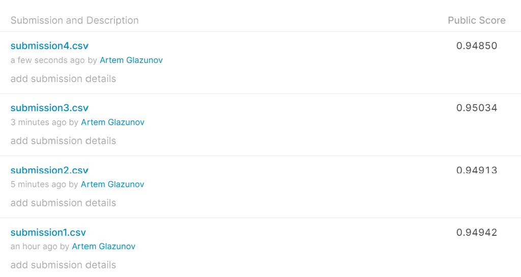

**Видно, что улучшение в качестве получено только для комбинации ответов логистической регрессии и градиентного бустинга, случайный лес улучшения в качестве не дал.**

**3.** Использование библиотеки **VowpalWabbit**

Попробуем воспользоваться библиотекой VowpalWabbit для улучшения качества в соревновании. Определим процедуру, которая получает на вход матрицы признаков без каких-либо преобразований и записывает необходимые файлы в формате vw для последующего использования в классификации.

```python
def arrays_to_vw_add_fe(Xs,Xc,Xn, y=None, train=True, out_file='palpatin.vw'):

    Xs = np.array(Xs,dtype=int)
    Xc = np.array(Xc)
    Xn = np.array(Xn,dtype=float)

    if train:
        with open(out_file, 'w') as vw_train_data:
            for yy,xs,xc,xn in zip(y,Xs,Xc,Xn):
                obj = str(yy)+' |session '+ ' '.join(map(str,xs)) +\
                      ' |cat ' + ' '.join([f'Fc{i+1}={val}' for i,val in enumerate(xc)]) +\
                      ' |num ' + ' '.join([f'Fn{i+1}:{val}' for i,val in enumerate(xn)]) + '\n'
                vw_train_data.write(obj)
    else:
        with open(out_file, 'w') as vw_test_data:
            for xs,xc,xn in zip(Xs,Xc,Xn):
                obj = '0 |session '+ ' '.join(map(str,xs)) +\
                      ' |cat ' + ' '.join([f'Fc{i+1}={val}' for i,val in enumerate(xc)]) +\
                      ' |num ' + ' '.join([f'Fn{i+1}:{val}' for i,val in enumerate(xn)]) + '\n'
                vw_test_data.write(obj)

    print('Good, Anakin!')
```

*Теперь воспользуемся результатами, полученными ранее, и составим необходимые матрицы.*

Матрица с сессиями

```python
Xs = train_test_df_sites.values
Xs.shape
```

```
(336358, 10)
```

Матрица с категориальными признаками

```python
Xcc=np.vstack([year,month,start_hour,unique_sites,day_of_week,TimeOfDay,\
                season,num_sites,num_sites_top10,num_sites_10sec]).T
Xc = np.hstack([added_fe1,Xcc])
Xc.shape
```

```
(336358, 13)
```

Матрица с вещественными признаками

```python
Xn = dur_array
Xn.shape
```

```
(336358, 9)
```

*Разделим полученные матрица на тренировочные и тестовые данные, а затем тренировочные разделим, в свою очередь, на 2 части.*

```python
Xs_train,Xc_train,Xn_train = Xs[:253561,:],Xc[:253561,:],Xn[:253561,:]
Xs_test,Xc_test,Xn_test = Xs[253561:,:],Xc[253561:,:],Xn[253561:,:]
```

```python
Xs_train_part,Xc_train_part,Xn_train_part = Xs_train[:train_share, :],Xc_train[:train_share, :],Xn_train[:train_share, :]
Xs_valid,Xc_valid,Xn_valid = Xs_train[train_share:, :],Xc_train[train_share:, :],Xn_train[train_share:, :]
```

```python
y_for_vw = [1 if yy == 1 else -1 for yy in y]
len(y_for_vw)
```

```
253561
```

```python
y_train_part_for_vw, y_valid_for_vw = y_for_vw[:train_share], y_for_vw[train_share:]
```

Запишем файлы с данными в формате vw

```python
%%time
arrays_to_vw_add_fe(Xs_train_part,Xc_train_part,Xn_train_part, y_train_part_for_vw,\
             out_file = os.path.join(PATH_TO_DATA,'train_part.vw'))
arrays_to_vw_add_fe(Xs_valid,Xc_valid,Xn_valid,\
             train = False, out_file = os.path.join(PATH_TO_DATA,'valid.vw'))
arrays_to_vw_add_fe(Xs_train,Xc_train,Xn_train, y_for_vw,\
             out_file = os.path.join(PATH_TO_DATA,'train.vw'))
arrays_to_vw_add_fe(Xs_test,Xc_test,Xn_test,\
             train = False, out_file = os.path.join(PATH_TO_DATA,'test.vw'))
```

```
Good, Anakin!
Good, Anakin!
Good, Anakin!
Good, Anakin!
Wall time: 40 s
```

```python
train_part_vw = os.path.join(PATH_TO_DATA, 'train_part.vw')
valid_vw = os.path.join(PATH_TO_DATA, 'valid.vw')
train_vw = os.path.join(PATH_TO_DATA, 'train.vw')
test_vw = os.path.join(PATH_TO_DATA, 'test.vw')
model = os.path.join(PATH_TO_DATA, 'vw_model.vw')
valid_pred = os.path.join(PATH_TO_DATA,'vw_valid_pred.csv')
pred = os.path.join(PATH_TO_DATA, 'vw_pred.csv')
```

Посмотрим на файлы

```python
!head -3 $train_vw
```

```
-1 |session 718 0 0 0 0 0 0 0 0 0 |cat Fc1=0 Fc2=0 Fc3=0 Fc4=2014 Fc5=2 Fc6=10 Fc7=2 Fc8=3 Fc9=1 Fc10=1 Fc11=1 Fc12=0 Fc13=1 |num Fn1:1800.0 Fn2:0.0 Fn3:0.0 Fn4:0.0 Fn5:0.0 Fn6:0.0 Fn7:0.0 Fn8:0.0 Fn9:0.0
-1 |session 890 941 3847 941 942 3846 3847 3846 1516 1518 |cat Fc1=0 Fc2=0 Fc3=1 Fc4=2014 Fc5=2 Fc6=11 Fc7=7 Fc8=5 Fc9=1 Fc10=1 Fc11=10 Fc12=0 Fc13=8 |num Fn1:0.0 Fn2:1.0 Fn3:0.0 Fn4:0.0 Fn5:0.0 Fn6:1.0 Fn7:0.0 Fn8:23.0 Fn9:1.0
-1 |session 14769 39 14768 14769 37 39 14768 14768 14768 14768 |cat Fc1=0 Fc2=0 Fc3=0 Fc4=2013 Fc5=12 Fc6=16 Fc7=4 Fc8=0 Fc9=2 Fc10=1 Fc11=10 Fc12=0 Fc13=10 |num Fn1:1.0 Fn2:1.0 Fn3:0.0 Fn4:0.0 Fn5:0.0 Fn6:1.0 Fn7:1.0 Fn8:1.0 Fn9:2.0
```

```python
!head -3 $test_vw
```

```
0 |session 29 35 22 321 23 2211 6730 21 44582 15336 |cat Fc1=0 Fc2=0 Fc3=1 Fc4=2014 Fc5=10 Fc6=11 Fc7=10 Fc8=5 Fc9=1 Fc10=4 Fc11=10 Fc12=0 Fc13=10 |num Fn1:0.0 Fn2:1.0 Fn3:0.0 Fn4:0.0 Fn5:0.0 Fn6:0.0 Fn7:0.0 Fn8:6.0 Fn9:0.0
0 |session 782 782 782 782 782 782 782 782 782 782 |cat Fc1=0 Fc2=0 Fc3=0 Fc4=2014 Fc5=7 Fc6=11 Fc7=1 Fc8=3 Fc9=1 Fc10=3 Fc11=10 Fc12=0 Fc13=1 |num Fn1:25.0 Fn2:5.0 Fn3:8.0 Fn4:3.0 Fn5:1.0 Fn6:13.0 Fn7:6.0 Fn8:1.0 Fn9:23.0
0 |session 55 55 55 55 55 55 55 55 1445 1445 |cat Fc1=0 Fc2=0 Fc3=0 Fc4=2014 Fc5=12 Fc6=15 Fc7=2 Fc8=4 Fc9=2 Fc10=1 Fc11=10 Fc12=0 Fc13=3 |num Fn1:1.0 Fn2:1.0 Fn3:61.0 Fn4:1.0 Fn5:1.0 Fn6:1.0 Fn7:1.0 Fn8:14.0 Fn9:3.0
```

Получим бейзлайн, для этого воспользуемся следующими параметрами

```python
%%time
!vw --passes 3 -c -k -b 18  --random_seed 17 -d $train_part_vw -f $model
```

```
final_regressor = capstone_user_identification\vw_model.vw
Num weight bits = 18
learning rate = 0.5
initial_t = 0
power_t = 0.5
decay_learning_rate = 1
creating cache_file = capstone_user_identification\train_part.vw.cache
Reading datafile = capstone_user_identification\train_part.vw
num sources = 1
average  since         example        example  current  current  current
loss     last          counter         weight    label  predict features
1.000000 1.000000            1            1.0  -1.0000   0.0000       25
0.719372 0.438743            2            2.0  -1.0000  -0.3376       28
0.431003 0.142634            4            4.0  -1.0000  -1.0000       33
0.229240 0.027477            8            8.0  -1.0000  -0.8042       28
0.122907 0.016574           16           16.0  -1.0000  -0.9538       29
0.066547 0.010186           32           32.0  -1.0000  -0.8717       27
0.035622 0.004697           64           64.0  -1.0000  -1.0000       32
0.018529 0.001435          128          128.0  -1.0000  -0.8892       27
0.029722 0.040916          256          256.0  -1.0000  -1.0000       32
0.025010 0.020297          512          512.0  -1.0000  -1.0000       28
0.036101 0.047193         1024         1024.0  -1.0000  -1.0000       28
0.030410 0.024719         2048         2048.0  -1.0000  -1.0000       27
0.032169 0.033928         4096         4096.0  -1.0000  -1.0000       30
0.033416 0.034663         8192         8192.0  -1.0000  -1.0000       31
0.030610 0.027804        16384        16384.0  -1.0000  -1.0000       33
0.030014 0.029419        32768        32768.0  -1.0000  -1.0000       33
0.026516 0.023018        65536        65536.0  -1.0000  -1.0000       28
0.024045 0.021574       131072       131072.0  -1.0000  -1.0000       28
0.021327 0.021327       262144       262144.0  -1.0000  -1.0000       26 h

finished run
number of examples per pass = 159743
passes used = 3
weighted example sum = 479229.000000
weighted label sum = -470517.000000
average loss = 0.017941 h
best constant = -0.981821
best constant's loss = 0.036028
total feature number = 14022567
```

```
Wall time: 1.71 s
```

```python
!vw -i $model -t -d $valid_vw -p $valid_pred
```

```
only testing
predictions = capstone_user_identification\vw_valid_pred.csv
Num weight bits = 18
learning rate = 0.5
initial_t = 0
power_t = 0.5
using no cache
Reading datafile = capstone_user_identification\valid.vw
num sources = 1
average  since         example        example  current  current  current
loss     last          counter         weight    label  predict features
1.000000 1.000000            1            1.0   0.0000  -1.0000       28
1.000000 1.000000            2            2.0   0.0000  -1.0000       29
1.000000 1.000000            4            4.0   0.0000  -1.0000       30
1.000000 1.000000            8            8.0   0.0000  -1.0000       25
0.980561 0.961122           16           16.0   0.0000  -1.0000       25
0.990280 1.000000           32           32.0   0.0000  -1.0000       29
0.995140 1.000000           64           64.0   0.0000  -1.0000       28
0.980154 0.965168          128          128.0   0.0000  -1.0000       33
0.970642 0.961130          256          256.0   0.0000  -1.0000       29
0.976228 0.981813          512          512.0   0.0000  -1.0000       32
0.981021 0.985814         1024         1024.0   0.0000  -1.0000       32
0.982968 0.984915         2048         2048.0   0.0000  -1.0000       33
0.984718 0.986467         4096         4096.0   0.0000  -1.0000       27
0.984177 0.983635         8192         8192.0   0.0000  -1.0000       31
0.983781 0.983386        16384        16384.0   0.0000  -1.0000       26
0.983770 0.983759        32768        32768.0   0.0000  -1.0000       33
0.982970 0.982169        65536        65536.0   0.0000  -1.0000       33

finished run
number of examples per pass = 76069
passes used = 1
weighted example sum = 76069.000000
weighted label sum = 0.000000
average loss = 0.983067
total feature number = 2226061
```

```python
print(f'AUC ROC score: {roc_auc_score(y_valid_for_vw,pd.read_csv(valid_pred,header=None))}')
```

```
AUC ROC score: 0.9412748257870784
```

Теперь подберем параметры на валидации

```python
for (loss, passes, bits) in itertools.product(['squared','logistic','hinge'],[2,3,5],[18,26,30]):

    !vw --passes $passes -c -k -b $bits --loss_function $loss --random_seed 17 -d $train_part_vw -f $model --quiet

    !vw -i $model -t -d $valid_vw -p $valid_pred --quiet


    print(f'Params: {loss} {passes} {bits}, AUC ROC score: {roc_auc_score(y_valid_for_vw,pd.read_csv(valid_pred,header=None))}')
    print('---------------')
```

```
Params: squared 2 18, AUC ROC score: 0.9376697200914003
---------------
Params: squared 2 26, AUC ROC score: 0.9376682151322436
---------------
```

```
internal error: memory allocation failed!
Error:  Failed to allocate weight array with 30 bits: try decreasing -b <bits>
```

```
Params: squared 2 30, AUC ROC score: 0.9376682151322436
---------------
Params: squared 3 18, AUC ROC score: 0.9412748257870784
---------------
Params: squared 3 26, AUC ROC score: 0.9412765703894129
---------------
```

```
internal error: memory allocation failed!
Error:  Failed to allocate weight array with 30 bits: try decreasing -b <bits>
```

```
Params: squared 3 30, AUC ROC score: 0.9412765703894129
---------------
Params: squared 5 18, AUC ROC score: 0.9455648891993471
---------------
Params: squared 5 26, AUC ROC score: 0.9455601155072448
---------------
```

```
internal error: memory allocation failed!
Error:  Failed to allocate weight array with 30 bits: try decreasing -b <bits>
```

```
Params: squared 5 30, AUC ROC score: 0.9455601155072448
---------------
Params: logistic 2 18, AUC ROC score: 0.9856392004399313
---------------
Params: logistic 2 26, AUC ROC score: 0.985638586953396
---------------
```

```
internal error: memory allocation failed!
Error:  Failed to allocate weight array with 30 bits: try decreasing -b <bits>
```

```
Params: logistic 2 30, AUC ROC score: 0.985638586953396
---------------
Params: logistic 3 18, AUC ROC score: 0.987012768035143
---------------
Params: logistic 3 26, AUC ROC score: 0.987010649589451
---------------
```

```
internal error: memory allocation failed!
Error:  Failed to allocate weight array with 30 bits: try decreasing -b <bits>
```

```
Params: logistic 3 30, AUC ROC score: 0.987010649589451
---------------
Params: logistic 5 18, AUC ROC score: 0.9881867607918606
---------------
Params: logistic 5 26, AUC ROC score: 0.9881816036706741
---------------
```

```
internal error: memory allocation failed!
Error:  Failed to allocate weight array with 30 bits: try decreasing -b <bits>
```

```
Params: logistic 5 30, AUC ROC score: 0.9881816036706741
---------------
Params: hinge 2 18, AUC ROC score: 0.8616185933505268
---------------
Params: hinge 2 26, AUC ROC score: 0.8608753544130886
---------------
```

```
internal error: memory allocation failed!
Error:  Failed to allocate weight array with 30 bits: try decreasing -b <bits>
```

```
Params: hinge 2 30, AUC ROC score: 0.8608753544130886
---------------
Params: hinge 3 18, AUC ROC score: 0.8729455006935849
---------------
Params: hinge 3 26, AUC ROC score: 0.8729219581477952
---------------
```

```
internal error: memory allocation failed!
Error:  Failed to allocate weight array with 30 bits: try decreasing -b <bits>
```

```
Params: hinge 3 30, AUC ROC score: 0.8729219581477952
---------------
Params: hinge 5 18, AUC ROC score: 0.8850914796612727
---------------
Params: hinge 5 26, AUC ROC score: 0.884387379247637
---------------
```

```
internal error: memory allocation failed!
Error:  Failed to allocate weight array with 30 bits: try decreasing -b <bits>
```

```
Params: hinge 5 30, AUC ROC score: 0.884387379247637
---------------
```

Лучшие параметры: логистическая функция потерь, 5 проходов по выборке, выделение 26 битов под признаки при хешировании, значение метрики качества на валидации AUC ROC score: 0.9881816036706741. Выбираем 26 бит, поскольку 18 может нехватить при использовании биграмм и триграмм.

Попробуем настроить регуляризацию, а также исследуем влияние биграмм

```python
%%time
for reg in [1e-1,1e-2,1e-3,1e-4,1e-5,1e-6,1e-7,1e-8,1e-9,1e-10,1e-11,1e-12]:

    !vw --passes 5 -c -k -b 26 --loss_function logistic --l2 $reg --random_seed 17\
    -d $train_part_vw -f $model --quiet

    !vw -i $model -t -d $valid_vw -p $valid_pred --quiet


    print(f'Param reg L2: {reg} , AUC ROC score: {roc_auc_score(y_valid_for_vw,pd.read_csv(valid_pred,header=None))}')
    print('---------------')
```

```
Param reg L2: 0.1 , AUC ROC score: 0.597066606463188
---------------
Param reg L2: 0.01 , AUC ROC score: 0.6477376418697198
---------------
Param reg L2: 0.001 , AUC ROC score: 0.8964325451232766
---------------
Param reg L2: 0.0001 , AUC ROC score: 0.9698354326203521
---------------
Param reg L2: 1e-05 , AUC ROC score: 0.9830426378509997
---------------
Param reg L2: 1e-06 , AUC ROC score: 0.9873262117260129
---------------
Param reg L2: 1e-07 , AUC ROC score: 0.9881561152222804
---------------
Param reg L2: 1e-08 , AUC ROC score: 0.9881797632110683
---------------
Param reg L2: 1e-09 , AUC ROC score: 0.9881809326697759
---------------
Param reg L2: 1e-10 , AUC ROC score: 0.9881817570423078
---------------
Param reg L2: 1e-11 , AUC ROC score: 0.9881816132564012
---------------
Param reg L2: 1e-12 , AUC ROC score: 0.988181603670674
---------------
Wall time: 8min 17s
```

```python
%%time
for reg in [1e-2,1e-3,1e-4,1e-5,1e-6,1e-7,1e-8,1e-9,1e-10,1e-11,1e-12]:

    !vw --passes 5 -c -k -b 26 --loss_function logistic --l1 $reg --random_seed 17\
    -d $train_part_vw -f $model --quiet

    !vw -i $model -t -d $valid_vw -p $valid_pred --quiet


    print(f'Param reg L1: {reg} , AUC ROC score: {roc_auc_score(y_valid_for_vw,pd.read_csv(valid_pred,header=None))}')
    print('---------------')
```

```
Param reg L1: 0.01 , AUC ROC score: 0.5
---------------
Param reg L1: 0.001 , AUC ROC score: 0.5
---------------
Param reg L1: 0.0001 , AUC ROC score: 0.9071376359342376
---------------
Param reg L1: 1e-05 , AUC ROC score: 0.9697976840269807
---------------
Param reg L1: 1e-06 , AUC ROC score: 0.9830979666678962
---------------
Param reg L1: 1e-07 , AUC ROC score: 0.987728687650309
---------------
Param reg L1: 1e-08 , AUC ROC score: 0.9881144939951554
---------------
Param reg L1: 1e-09 , AUC ROC score: 0.98814386466303
---------------
Param reg L1: 1e-10 , AUC ROC score: 0.9881919083273205
---------------
Param reg L1: 1e-11 , AUC ROC score: 0.9881827539579275
---------------
Param reg L1: 1e-12 , AUC ROC score: 0.9881816420135825
---------------
Wall time: 1min 20s
```

Итак, настройка регуляризации не улучшает качество на валидации, перейдем к биграммам и триграммам

```python
!vw --link=logistic --passes 5 -c -k -b 26 --loss_function logistic --ngram 2 --random_seed 17\
    -d $train_part_vw -f $model --quiet

!vw -i $model -t -d $valid_vw -p $valid_pred --quiet


print(f'AUC ROC score: {roc_auc_score(y_valid_for_vw,pd.read_csv(valid_pred,header=None))}')
```

```
AUC ROC score: 0.9905075995261123
```

```python
!vw --link=logistic --passes 5 -c -k -b 26 --loss_function logistic --ngram 3 --random_seed 17\
    -d $train_part_vw -f $model --quiet

!vw -i $model -t -d $valid_vw -p $valid_pred --quiet


print(f'AUC ROC score: {roc_auc_score(y_valid_for_vw,pd.read_csv(valid_pred,header=None))}')
```

```
AUC ROC score: 0.9928451653541761
```

*Итак, использование триграмм повысило качество. Попробуем обучить на данных соревнования и проверить качество.*

```python
%%time
!vw --link=logistic --passes 5 -c -k -b 26 --loss_function logistic --ngram 3 --random_seed 17\
    -d $train_vw -f $model --quiet

!vw -i $model -t -d $test_vw -p $pred --quiet

df_pred = pd.read_csv(pred,header=None)
df_pred.head()
```

```
Wall time: 41.7 s
```

|  | 0 |
| --- | --- |
| 0 | 0.000232 |
| 1 | 0.000000 |
| 2 | 0.000000 |
| 3 | 0.000000 |
| 4 | 0.000000 |

```python
write_to_submission_file(df_pred.values.reshape(-1),out_file='submission5.csv')
```

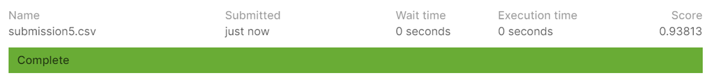

**К сожалению, даже несмотря на высокое качество на валидации, в соревновании увеличения качества по сравнению с уже достигнутым не получено.**

### 5. Визуализация полученных результатов. Выводы

Построим ROC кривую для лучшего SGD алгоритма.

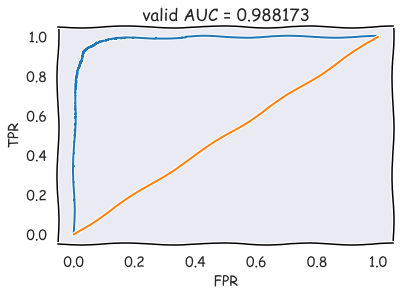

```python
sgd_clf4.fit(X_train, y_train)
sgd_clf4_valid_pred_proba = sgd_clf4.predict_proba(X_valid)
ROC_AUC_sgd_clf4 = roc_auc_score(y_valid,sgd_clf4_valid_pred_proba[:,1])
roc_curve_sgd = roc_curve(y_valid,sgd_clf4_valid_pred_proba[:,1])
with plt.xkcd():
    plt.plot(roc_curve_sgd[0], roc_curve_sgd[1]);
    plt.plot([0,1], [0,1])
    plt.xlabel('FPR'); plt.ylabel('TPR'); plt.title('valid AUC = %f' % (ROC_AUC_sgd_clf4)); plt.axis([-0.05,1.05,-0.05,1.05]);
```

Посмотрим отчет о классификации на валидационной выборке

```python
print(classification_report(y_valid,sgd_clf4.predict(X_valid)))
```

```
              precision    recall  f1-score   support

           0       1.00      0.97      0.99     75377
           1       0.24      0.88      0.37       692

    accuracy                           0.97     76069
   macro avg       0.62      0.93      0.68     76069
weighted avg       0.99      0.97      0.98     76069
```

Видно, что точность определения 1-го класса (Алиса) невелика, что, вероятно, связано с порогом. Попробуем подобрать оптимальный порог.

```python
precisions=[]
recalls=[]
thrshs=[0.1,0.2,0.3,0.5,0.6,0.7,0.8,0.9,0.95,0.96,0.97,0.99]
for threshold in thrshs:
    y_pred = [1 if prob > threshold else 0 for prob in sgd_clf4_valid_pred_proba[:,1]]
    precisions.append(precision_score(y_valid,y_pred))
    recalls.append(recall_score(y_valid,y_pred))
```

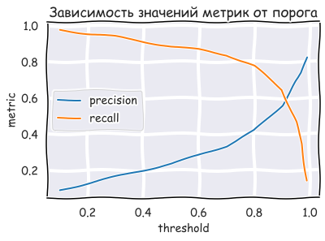

```python
with plt.xkcd():
    plt.plot(thrshs, precisions,label='precision');
    plt.plot(thrshs, recalls,label='recall');
    plt.xlabel('threshold')
    plt.legend()
    plt.title('Зависимость значений метрик от порога')
    plt.grid()
    plt.ylabel('metric');
```

**Итак, в рамках данного проекта удалось подготовить и исследовать данные, подобрать алгоритм и получить результаты в соревновании на Kaggle в рамках задачи идентификации пользователя по его активности в интернете. Такая задача может быть полезна как в случае предотвращения мошеннических действий, так и, вероятно, в работе спец. служб. К сожалению, существует ряд проблем. Во-первых, задача сильно несбалансирована, что может сказаться на качестве для некоторых алгоритмов. Во-вторых, данных необходимо очень много, их надо определенным образом собрать, при этом для линейных алгоритмов такое увеличение количества данных в какой-то момент перестанет давать прирост в качестве (в нашем случае метрики классификации не очень высоки, но можно несколько улучшить качество добавлением данных). В-третьих, что самое важное, существует этическая проблема такого сбора данных, плюс нужна юридическая оценка правомерности таких действий с точки зрения закона "О персональных данных", особенно в случае идентификации с ФИО. Но в любом случае, данная задача очень интересна.**